Nanoparticles use for Delivering

Ursolic Acid in Cancer Therapy: A

Scoping Review

Andang Miatmoko <sup>1</sup><sup>,</sup><sup>2</sup>*, Ester Adelia Mianing <sup>3</sup>, Retno Sari <sup>1</sup>and Esti Hendradi <sup>1</sup>

1Department of Pharmaceutical Sciences, Faculty of Pharmacy, Universitas Airlangga, Surabaya, Indonesia, 2Stem Cell Research

and Development Center, Universitas Airlangga, Surabaya, Indonesia, <sup>3</sup>Study Program of Pharmacy, Faculty of Pharmacy,

Universitas Airlangga, Surabaya, Indonesia

Ursolic acid is a natural pentacyclic triterpenoid that exerts a potent anticancer effect.

Furthermore, it is classiﬁed as a BCS class IV compound possessing low permeability and

water solubility, consequently demonstrating limited bioavailability in addition to low

therapeutic

effectiveness.

Nanoparticles

are

developed

to

modify

the

physical

providing highly effective cancer therapy due to the Enhanced Permeation and

Retention (EPR) Effect. This study aims to provide a review of the efﬁcacy and safety

of various types of Ursolic Acid-loading nanoparticles within the setting of preclinical and

clinical anticancer studies. This literature study used scoping review method, where the

The identiﬁcation stage produced 237 suitable articles. Duplicate screening was then

conducted followed by the initial selection of 18 articles that had been reviewed and

extracted for data analysis. Based on this review, the use of nanoparticles can be seen to

increase the anticancer efﬁcacy of Ursolic Acid in terms of several parameters including

pharmacokinetic data, survival rates and inhibition rates, as well as the absence of serious

toxicity in preclinical and clinical trials in terms of several parameters including body weight,

blood clinical chemistry, and organ histipathology. Based on this review, the use of

nanoparticles has been able to increase the anticancer efﬁcacy of Ursolic Acid, as well as

show the absence of serious toxicity in preclinical and clinical trials. Evenmore, the

liposome carrier provides development data that has reached the clinical trial phase I.

The use of nanoparticle provides high potential for Ursolic Acid delivery in cancer therapy.

Keywords: ursolic acid, cancer, nanoparticle, liposome, nanosphere, polymeric micelle, efﬁcacy, toxicity

INTRODUCTION

Cancer is a disease that can occur in almost any organ or tissue of the body when abnormal cells grow

uncontrollably beyond their usual limits to invade adjacent parts of the body and/or spread to other

organs (Kamińska et al., 2015). Data from the Global Burden of Cancer released by the World Health

Organization (WHO) reported that the number of cases and deaths from cancer in 2018 totaled 18.1

million and 9.6 million respectively. Cancer-related deaths are predicted to increase to more than

13.1 million by 2030 (Internatioanl Agency for Research on Cancer, 2018). The most common types

affecting men include lung, prostate, colorectal, and liver cancer, while in women, they comprise

breast, colorectal, lung, cervical and thyroid cancers. In 2018, the incidence rate of liver cancer in

Edited by:

Michael Whittaker,

Monash University, Australia

Reviewed by:

Khalid Saad Alharbi,

Jouf University, Saudi Arabia

Yong Sze Ong,

Monash University Malaysia, Malaysia

*Correspondence:

Andang Miatmoko

andang-m@ff.unair.ac.id

Specialty section:

This article was submitted to

Pharmacology of Anti-Cancer Drugs,

a section of the journal

Frontiers in Pharmacology

Received: 30 September 2021

Accepted: 29 November 2021

Published: 24 December 2021

Citation:

Miatmoko A, Mianing EA, Sari R and

Hendradi E (2021) Nanoparticles use

for Delivering Ursolic Acid in Cancer

Therapy: A Scoping Review.

Front. Pharmacol. 12:787226.

doi: 10.3389/fphar.2021.787226

Frontiers in Pharmacology | www.frontiersin.org

December 2021 | Volume 12 | Article 787226

1

REVIEW

published: 24 December 2021

doi: 10.3389/fphar.2021.787226

Indonesia ranked eighth highest in Southeast Asia, while in Asia

as a whole it occupied 23rd position with 348,809 cases

(Globocan. Indonesia - Global Cancer Observatory WHO, 2018).

The ﬁrst-line options for cancer treatment include surgery,

radiotherapy and the administering of biological and chemical

drugs

(chemotherapy,

hormones,

and

biological

therapy).

However, such forms of treatment fail to control metastatic

tumors that have spread to other organs (Kumari et al., 2016).

Chemotherapeutic agents are predominantly toxic compounds

that primarily inhibit the rapid proliferation of cancer cells, while

also potentially restricting the growth of hair follicle, bone

marrow

and

gastrointestinal

cells

culminating

in

severe

undesired side effects (Pérez-Herrero and Fernández-Medarde,

2015). Consequently, the effect of certain natural compounds

have been widely explored and it has been scientiﬁcally proven

that Ursolic Acid (UA), an active agent, inhibits the proliferation

of cancer cells (Kashyap et al., 2016).

UA is a natural pentacyclic triterpene of the cyclosqualenoid

family present in many plants which can modulate cellular

transcription factors, growth factor receptors, inﬂammatory

cytokines, and numerous other molecular targets that regulate

cell

proliferation,

metastasis,

apoptosis,

angiogenesis,

and

autophagy. The anticancer effects of UA have been reported

for many types of cancer, one of which is liver cancer (Khwaza

et al., 2020). The mechanisms of UA which produce such effects

include nuclear-kappa B (NF-kB) factors and apoptosis signaling

in cancer cells (Seo et al., 2018). The protease activity involving

urokinase and cathepsin B, both of which are known to be

associated

with

tumor

invasion

and

metastasis,

is

also

signiﬁcantly inhibited by UA, interleukin-1 β (IL-1β), Tumor

necrotic factor-α (TNF-α), and the expression of MMP-2 and

MMP-9 (Mitochondria-Mediated Pathway) (Kashyap et al., 2016;

Ali et al., 2019). Prolonged administration of excessive doses of

UA, with an LD50 value of 9.26 g/kg in acute toxicity tests on

mice (Sun et al., 2020), has the potential to cause liver cytotoxicity

which

is

not

classiﬁed

as

genetic

toxicity.

Within

the

Biopharmaceutical

Classiﬁcation

System

(BCS),

UA

categorized as a BCS class IV compound demonstrating low<sup>is</sup>

permeability and solubility (Sun et al., 2020) which, consequently,

requires a nanotechnology-based drug delivery system to reach

the desired target (Biopharmaceutical, 2011). In particular, the

development of drug delivery systems entails the use of

nanoparticles

targeted

at

cancer

cells

which

signiﬁcantly

improve therapeutic and diagnostic efﬁcacy as well as reducing

unwanted side effects.

Nanotechnology represents a new therapeutic platform that

employs nanoparticles (NPs) in the diagnosis and treatment of

cancer. NPs are used in cancer therapy due to their relatively

small size, 1–1,000 nm, the fact that they frequently fall within the

range of 10–200 nm, and the presence of the EPR effect (Rajesh,

2000; Reddy, 2005; Fang et al., 2011). Nano-drug delivery systems

have been lauded for their excellent biocompatibility properties,

low toxicity, increased solubility in water, in addition to their

ability to deliver targeted drugs to tissues which limits their

accumulation in the kidneys, liver, spleen, and other non-

targeted organs, while improving therapeutic efﬁcacy (Kumari

et al., 2016; Li et al., 2017). The delivery of nanoparticles to tumor

tissues through systemic circulation can be executed through two

targeting

strategies,

including

passive

targeting,

when

nanoparticles entering circulation will accumulate at the tumor

site due to enhanced permeation and retention (EPR). In contrast,

active targeting, generally employs ligand molecules such as

antibodies

and

peptides

to

recognize

speciﬁc

antigens

expressed in tumor cells or the microenvironment (Kumari

et al., 2016).

Many types of nanoparticles exist, including polymeric

therapy (polymer-protein and polymer-drug conjugates) in

which drugs are covalently bound or conjugated to polymer

structures and nanoparticulate drugs. The drugs are physically

trapped in assembled particles composed of different materials

such as polymers (polymer micelles, dendrimers and polymer

nanoparticles), lipids (liposomes), or organometallic compounds

(carbon

nanotubes).

The

ﬁrst

generation

of

anticancer

nanoparticles approved by the FDA include liposomal drugs

and polymer conjugates (Barenholz, 2012; Pérez-Herrero and

Fernández-Medarde, 2015). However, certain products can be

subjected to in vivo and clinical trials, while others remain limited

to in vitro studies. Therefore, the effectiveness and safety of the

nanoparticle drug constitute important assessed parameters.

As for the development of drugs with nanoparticle carriers,

one example is Doxil<sup>®</sup>, the ﬁrst nano-drug using liposomes

approved

by

the

FDA,

which

demonstrates

the

clinical

performance

advantages

of

doxorubicin

in

a

variety

neoplastic conditions due to pharmacokinetics and the unique<sup>of</sup>

EPR-related

biodistribution

of

liposomal

doxorubicin

(Barenholz, 2012; Wei et al., 2016). Doxil<sup>®</sup>can reduce side

effects,

especially

that

of

cardiac

toxicity,

and

improve

patients’ adherence and quality of life (Barenholz, 2012).

Cisplatin is an anticancer drug prepared with a polymeric

micelle through the formation of a metal-polymer complex

between

cisplatin

and

poly-(ethylene

glycol)-poly(glutamic

acid) block copolymers (Nishiyama et al., 2003; Uchino et al.,

2005). These micelles are 28 nm in size with a very narrow

distribution,

demonstrate

extremely

extended

blood

circulation, and accumulate effectively in solid tumor models

of Lewis lung carcinoma cells. However, because they undergo

chemical synthesis, toxicity and scale-up production become

major issues (Mizumura et al., 2001; Plummer et al., 2011;

Mitchell

et

al.,

2021).

In

addition,

the

development

Abraxane<sup>®</sup>, a paclitaxel-albumin-bound nanoparticle ∼130 nm<sup>of</sup>

in size, was approved by the FDA in 2005 for the treatment of

metastatic breast cancer (Miele et al., 2009; Ma and Mumper,

2013). This formulation has been shown to have several

advantages in terms of toxicity reduction compared to Taxol<sup>®</sup>.

Moreover, the total dose can be given within 30 min without pre-

treatment. However, the manner in which Abraxane<sup>®</sup>can

improve survival rates and overcome P-GP-mediated drug

resistance remains unclear (Ma and Mumper, 2013).

Certain nanoparticles have been used in the delivery of UA as a

cancer therapy including liposomes, polymeric nanoparticles,

and polymeric micelles (Zaimy et al., 2017). However, at the

time of writing, in contrast to other chemotherapy drugs such as

Doxorubicin

(Doxil<sup>®</sup>),

Cisplatin,

Paclitaxel

(Taxol<sup>®</sup>),

or

Amphotericin B (Ambisome<sup>®</sup>), no review of the effectiveness

Frontiers in Pharmacology | www.frontiersin.org

December 2021 | Volume 12 | Article 787226

2

Miatmoko et al.

Nanoparticles use for Ursolic Acid

and safety of several types of nanoparticles for the delivery of UA

for cancer therapy has been conducted (Zaimy et al., 2017). This

study aims to provide a literature review related to the anticancer

effectiveness and safety of UA delivered with various types of

nanoparticles based on pre-clinical and clinical trial results from

existing research published between 2011 and 2021.

METHODS

Article Selection Criteria

This study uses the scoping review method involving literature

accessible through the PubMed, Sciencedirect, Scopus, and

Google

Scholar

databases

consisting

of

online

research

publications dating from 2011 to 2021. Clinical trial articles

were sourced using the keywords"Clinical trial”, “Ursolic

Acid”, “Cancer”, and “OR Nanoparticle Liposome”. As for the

search for articles relating to in vivo studies, this employed the

keywords “Pre-Clinical OR in vivo OR Animal”, Ursolic Acid”,

“Cancer”, “Nanoparticle”. Within this study, several inclusion

and exclusion criteria were applied to select and screen articles for

review as shown in Table 1.

Evaluation of Physical Characteristics of UA

Nanoparticles

Data analysis involved comparing the physical characteristics of

different types of nanoparticles identiﬁed in the selected articles.

Analysis of Particle Size

Particle size and particle size distribution produce signiﬁcant

impacts on drug loading variation, drug release, bioavailability,

and efﬁcacy (Kharia et al., 2012). In addition, particle sizes of

150 nm to 4.5 μm will be easily recognized by macrophages and

dendritic cells during phagositosis (Koppolu and Zaharoff, 2013).

Instruments

used

in

nanoparticle

size

and

morphology

determination

include

Dynamic

Light

Scattering

(DLS),

Scanning Electron Microscopy (SEM), Transmission Electron

Microscopy (TEM), and Atomic Force Microscopy (AFM).

Analysis of ζ-Potential

Zeta potential is used to predict the stability of colloidal

dispersion systems during storage. Generally, ζ-potential values

above ± 30 mV resulted in more stable particles because the

repulsing force between particles can prevent aggregation. The

ζ-potential is affected by surfactants, polymers, the surface active

agent component of nanoparticles, the presence of absorbing

compounds, dispersed phase media, ionic strength, and pH

(Kharia et al., 2012). The ζ-potential can be analyzed using the

Electrophoretic Light Scattering (ELS) method (Miatmoko et al.,

2017; Wang et al., 2017).

Analysis of Encapsulation Efﬁciency

Entrapment Efﬁciency (EE%), or encapsulation efﬁciency, is

deﬁned as the portion of drugs encapsulated in nanoparticles.

Free drugs that are not encapsulated in the drug delivery carriers

or nanoparticles can be separated by means of centrifugation,

dialysis,

or

gel

chromatography.

The

concentration

of

entrapped

and

un-entrapped

drugs

can

be

determined

through the use of instruments such as spectrophotometers

or high-performance liquid chromatography (HPLC). The

encapsulation efﬁciency percentage is calculated using the

following equation:

EE(%) � <sup>W</sup><sup>T</sup><sup>−</sup><sup>W</sup><sup>U</sup>

WT

x 100%

where, WT is the total weight of AU and WU is an un-entrapped

UA weight (Poudel et al., 2020).

TABLE 1 | The inclusion and exclusion criteria for article screening and selection.

Test parameters

Inclusion criteria

Exclusion criteria

Type of research

a) Randomized or non-randomized phases 1, 2, or 3 clinical trials

a) In vitro study

b) Ex vivo study

b) In vivo studies in animals

c) Review article

Intervention

a) Native UA as an active ingredient

a) Extracts containing UA and UA derivates

b) Nanoparticles (lipids, polymers, hybrid nanoparticles as carriers)

b) Microparticles or other carrier systems more than 1,000 nm in

size

c) Administration routes comprise oral route in addition to intravenous,

intraperitoneal, and intratumoral injection

c) Administration routes other than those meeting the inclusion

criteria (topical, transdermal)

d) Healthy patients and those suffering from all types of cancer (both individuals who

have undergone surgery and those who have not)

Comparison

a) No comparison with other drugs, only negative controls

-

b) Comparison with other drugs

Outcome

a) Primary efﬁcacy outcomes (improved lifespan, enhanced survival rate, tumor

growth inhibition)

-

b) Secondary efﬁcacy outcomes (e.g., blood parameters, no complaints);

improvement in physical condition (body weight, tissue histopathology); clinical and

non-clinical improvements

c) Toxicity (body weight, blood parameters, clinical parameters, non-clinical

parameters, adverse events, organ histopathology)

Types of

Publications

a) Articles are written in English

The article is not written in English

b) Not included as predatory journals

Frontiers in Pharmacology | www.frontiersin.org

December 2021 | Volume 12 | Article 787226

3

Miatmoko et al.

Nanoparticles use for Ursolic Acid

Pharmacokinetic Evaluation of UA

Nanoparticles

Plasma concentration versus time data was analyzed using non-

compartmental methods. Peak plasma concentration (Cmax )

and time-to-peak plasma concentrations (Tmax) were obtained

through experimental observation. In elimination half-life (t1/2 )

calculated as 0.693/λz, λz is the slope of the terminal phase. In

areas under the curve (AUC0−t) of plasma concentration versus

time from zero to inﬁnity, AUC0−∞ is equivalent to the total area

from time � 0 to the last measurable concentration time. The

value is calculated using the linear trapezoidal method up to

Cmax ,

log-trapezoidal

method

(until

the

last

measured

concentration), and extrapolated areas (Zhu et al., 2013). In

this

study,

the

analysis

was

conducted

by

comparing

pharmacokinetic proﬁles from various studies contained in the

articles reviewed.

Evaluation of the Effectiveness of Ursolic

Acid Nanoparticles

The analysis was conducted by comparing the results of efﬁcacy

studies including survival rate, tumor growth inhibition, tumor

weight, and tumor volume, as well as tumor tissue histopathology

extracted from reviewed articles.

Cancerous Tissue Histopathology

The

histological

section

of

the

liver

was

stained

with

haematoxylin and eosin (H&E) staining and subsequently

compared to the histopathological appearance of each organ in

the control and treatment groups (Melo et al., 2020). The

microstructure and morphology of tissues were observed using

a light microscope (Wang et al., 2017). Hematoxylin is a base dye

that has an afﬁnity for the acidic components of cells, primarily

the nucleic acids contained in the nucleus, while eosin is an acidic

dye that binds to the cell cytoplasm. As a result, H&E stained the

core blue and cytoplasm orange-red (Slaoui and Fiette, 2011).

Analysis of Relative Tumor Volume

In the articles, the size of the tumor is determined by means of a

calliper, while its volume is calculated using the following

equation:

V � 0.5xy<sup>2</sup>

where x is the longest and y the shortest diameter (Hattori et al.,

2014; Yang et al., 2014; Wang et al., 2016; Miatmoko et al., 2017;

Liu et al., 2021). In this study, the relative tumor volume is

calculated using the following formulas:

relative tumor volume �

VT NC

VT AUNP

or

relative tumor volume �

VT AU

VT AUNP

where VT NC is the volume of the negative control group tumor,

VT AU is the volume of the native UA treatment group tumor,

and VT AU NP is the volume of the UA nanoparticle treatment

group tumor.

Analysis of Relative Tumor Weight and

Growth Inhibition Rate

The antitumor activity of nanoparticles is assessed through the

tumor growth inhibition rate (IR) or tumor growth inhibition

(TGI) at the experimental endpoint, calculated using the

following equations:

IR (%) or TGI (%) �

WT of negative control group − WT of treatment group

WT of negative control group

where WT is the weight of the tumor (Wang et al., 2017; Shen

et al., 2018; Fu et al., 2021). In this study, the relative tumor weight

and relative inhibition rate were each calculated using the

following formulas:

Relative tumor weight �

WT NC

WT AUNP

or

relative tumor weight �

WT AU

WT AUNP

where WT NC is the weight of the negative control group tumor,

WT AU is the tumor weight of the native UA treatment group,

and WT AUNP is the volume of the UA nanoparticle treatment

group tumor.

Relative inhibition rate � <sup>I</sup><sup>R</sup><sup>AUNP</sup>

IR AU

where IR AUNP is the tumor inhibition rate of UA nanoparticle

treatment group, and IR AU represents the tumor inhibition rate

of the native UA treatment group.

Analysis of Relative Survival Rate

Survival rates can be used as a standard assessment of effective

therapy. The survival period is usually calculated from the date of

diagnosis or commencement of the treatment period. The

survival curve of each group was estimated using the Kaplan-

Meier method with the average survival time difference being

assessed by means of a log-rank test (Yang et al., 2014). This

method involves non-parametric estimation of the survival

function commonly used to describe the survival of a single

population or compare the survival of two populations. The

Kaplan-Meier estimate is one of the most effective statistical

methods of measuring the probability of a patient’s survival

observed during a post-treatment period (Etikan, 2017). In

this study, the relative survival rate was calculated using the

following formula:

Relative survival rate � <sup>S</sup><sup>R</sup><sup>AUNP</sup>

SR NC

where SR AUNP is the survival rate following the administration

of UA nanoparticles and SR NC is the survival rate of the negative

controls.

Frontiers in Pharmacology | www.frontiersin.org

December 2021 | Volume 12 | Article 787226

4

Miatmoko et al.

Nanoparticles use for Ursolic Acid

Evaluation of Toxicity of UA Nanoparticles in

Pre-Clinical Trials

Weight Analysis

Weight loss represents a signiﬁcant parameter of biological safety

analysis or drug safety. The weight of the mice subjects is

measured on the day of tumor inoculation and continues

daily, or at least several times per week, during treatment.

Each treatment group mouse is quantitatively weighed with

the result being compared to that of a normal mouse in order

to identify any signiﬁcant difference between the two groups

(Valcourt et al., 2020). In this study, the weight of the mice was

calculated using the following formulas:

Relative body weights �

WB NC

WB AUNP

or

Relative body weights �

WB AU

WB AUNP

Where WB NC is the mice body weight in the administration of

negative control, WB AU is the mice body weight in the

administration of native UA, and WB AUNP represents the

mice body weight in the administration of UA nanoparticles.

Other Toxicity Analysis

Other toxicity data on the in vivo studies was derived by data

recapitulation that included: tissue histopathology, increased

levels of ALT and AST, and the amount of WBC as an

indicator of hematological toxicity (Zhao et al., 2018; Li et al.,

2019; Liu et al., 2021).

Evaluation of AU-NP Toxicity in Clinical

Trials

Analysis of Clinical Chemistry Data

Toxicity was evaluated in all subjects treated with at least one

cycle of UA Liposome therapy. Hematological parameters (red

blood cells, WBC, hemoglobin, ANC, and platelets), urinary

routines (urine protein, glucose, erythrocytes, leukocytes, and

urine bilirubin), and stool routines (stool erythrocytes and stool

leukocytes) were evaluated. Blood biochemistry including ALT,

AST, ALP, gamma-glutamyl transpeptidase (GGT) were further

analyzed (Qian et al., 2015). In this study, the analysis was

conducted by comparing clinical laboratory data (ALT, AST,

GGT, DBIL, and TBIL) extracted from reviewed articles.

Analysis of Adverse Events

Adverse events are used to assess unintended events (AE) in

healthy adult volunteers and patients with advanced solid tumor

disease. In addition, the toxicity can be seen from the value of

the maximum tolerated dose (MTD) used to determine the

highest dose of the drug that can be administered without

adverse events. The adverse events documented during the

study were classiﬁed as mild, moderate, or severe based on

the dosage (Valcourt et al., 2020). In this study, the analysis was

conducted by comparing adverse events or side effects occurring

in subjects who had received the treatment mentioned in

reviewed articles.

RESULTS AND DISCUSSION

This study provides a literature review focusing on the anticancer

effectiveness and safety of UA delivered with various types of

nanoparticles to increase its anticancer effects as conﬁrmed by

both pre-clinical and clinical trials. Literature searches of all four

databases using pre-determined keywords identiﬁed 237 articles

in the prescreening stage as can be seen in Figure 1. Of the total

literature reviewed, duplication screening was conducted using

the Mendeley application to produce a ﬁnal body of 226 articles.

Application of exclusion criteria resulting in a body of 196

selected

articles

which

were

subsequently

subjected

to

inclusion criteria to produce a ﬁnal total of 30. The initial

selection process identiﬁed 24 articles which were subsequently

reviewed, culminating in 18 which satisﬁed the inclusion criteria.

The summary of reviewed articles is presented in Table 2.

The data extraction of the literature used can be seen in

Table 2.

Nanoparticle Characterization Results

From the review of the 18 articles, it was clear that three types of

drug represent the most frequent delivery carriers of UA as an

anticancer agent, namely; Liposome (50%), Nanosphere (39%)

and Polymeric Misel (11%), (see Figure 2A).

According to the review results, several characterization

parameters of liposomes, nanospheres, and polymeric micelles

exist, including particle size, ζ-potential, and encapsulation

efﬁciency (EE). From the data analysis of the 18 articles, the

size of liposome particles was found to range from 70 to 200 nm

(67%); nanosphere particle size to be between 70 and 200 nm

(100%); and micelle polymeric particle size to be between 30 and

70 nm (50%). The ζ-potential of liposomes ranged from (−)30 to

0 mV (11%) and 0 to (+)30 mV (33%), while the nanosphere

ζ-potentials were between (-)30 to 0 mV (57%), 0 to (+)30 mV

≥90% (14%) and 30–90% (14%); as for EE polymeric micelles,

these are not mentioned in the article, as presented in Figure 2B.

Characterization of liposome particle size is important because

it affects the interaction of liposomes with target cells as well as

the elimination, penetration and retention of drugs in the target

sites (Monteiro et al., 2014). Phospholipids represent the main

constituents of liposomal membranes and the use of lipid types

and ratios within different preparation methods can affect the size

of liposomes (Monteiro et al., 2014; Shaker et al., 2017). From

injection and thin-ﬁlm hydration methods have particle sizes

ranging from 70 to 200 nm. This ﬁnding is in accordance with

that of previous research arguing that, with the ethanol injection

method, liposome could be generated as SUVs with diameters of

30–110 nm (Akbarzadeh et al., 2013; Monteiro et al., 2014), while

with the adoption of thin ﬁlm hydration methods, continued use

of sonication or extrusion processes can produce liposomes as

25 nm to 1 μm-sized ULVs (Monteiro et al., 2014). Liposome size

depends on that of the phospholipid molecule assembly whose

average dimensions depend on their lipid composition, while it is

supposed that the size of liposome particles increases slightly with

Frontiers in Pharmacology | www.frontiersin.org

December 2021 | Volume 12 | Article 787226

5

Miatmoko et al.

Nanoparticles use for Ursolic Acid

a reduction in the molar ratio of HSPC/SPC in the range of

119–143 nm (Chen et al., 2006). On the other hand, liposomes

made from DMPC, DSPC, and HSPC (at a weight ratio of 2:1 to

cholesterol) experienced different increases in particle size, e.g.,

DMPC:Chol liposomes increased in size from 149 to 190 nm,

DSPC:Chol expanded from 83 to 104 nm, and HSPC:Chol

liposomes from 88 to 122 nm (Webb et al., 2019).

For nanospheres, particle size, which is greatly affected by lipid

type, ranges from 70 to 200 nm. This is in accordance with a

previous report stating that nanospheres have a diameter of

10–200 nm (Baldim et al., 2020). With regard to polymeric

micelles,

studies

show

that

particle

sizes

ranging

from

30–70 nm

are

affected

by

polymer

types

based

on

the

characteristics

of

hydrophilic

and

hydrophobic

block

copolymers. This ﬁnding is in keeping with that of earlier

research which reported that the size of polymeric micelle

particles is determined by the ratio of hydrophobic and

hydrophilic block chains and can produce particle sizes of

≤50 nm (Cabral et al., 2011). Increased targeting of drugs to

cancer cells within the tumor tissues with the use of long-

circulating polymeric micelles depends on the size of the

micelle and the vascular permeability of the tumor tissues. In

hypervascular tumors with highly permeable vascular structures,

sub-100 nm polymeric micelles show no limits for drug

extravasation and tumor penetration. In contrast, only micelles

smaller than 50 nm can penetrate hipovascular tumors whose

vascular permeability is poor (Cabral et al., 2011).

The zeta potentials which reﬂect the liposome surface charges

were evaluated (Alves et al., 2017). Figure 2B shows that

liposomes and nanospheres had zeta potentials ranging from

(−30) to 0 mV and 0 to (+)30 mV, while those of polymeric

micelles varied from (−30) to 0 mV. If the system has a strong

negative or positive zeta potential the particles will tend to repulse

each other and no aggregation occurs. Therefore, if the system has

zeta potential >+30 mV or <−30 mV, then it can be considered

stable (Laouini et al., 2012; Lunardi et al., 2021). The positive or

negative charges measured in nanoparticles are highly dependent

on lipid components. Analysis of the composition and intracellular

delivery mechanisms conﬁrmed that conventional liposomes had a

relative neutral charge

due

to their neutral phospholipid

composition such as HSPC and became negatively charged

when added to cholesterol. pH sensitive liposomes contained a

DOPE-like phospholipid component with CHEMS causing their

negative

charges;

cationic

liposomes

had

a

cationic

lipid

composition

such

as

DDAB,

DOGS,

DOTAP,

DOTMA,

DMRIE, DORIE with DOPE; Long-circulating liposomes (LCL)

had a high TC neutral lipid composition, cholesterol, added to

approximately 5–10 mol % of PEG-DSPE rendering these

liposomes stable when under protein opsonization (Sharma and

Sharma, 1997; Gabizon et al., 2012).

The tendency of a drug to interact with polar or non-polar

bonds and/or electrostatic interactions with lipid bilayer will

determine whether it will be encapsulated into inner aqueous

compartments or the lipid bilayer membrane, or whether it will

be closely related to the polar head group of the bilayer membrane

through

electrostatic

interactions.

It

will

correlate

to

encapsulation efﬁciency (EE) or loading capacity, which is

usually deﬁned as a fraction of the percentage of the total

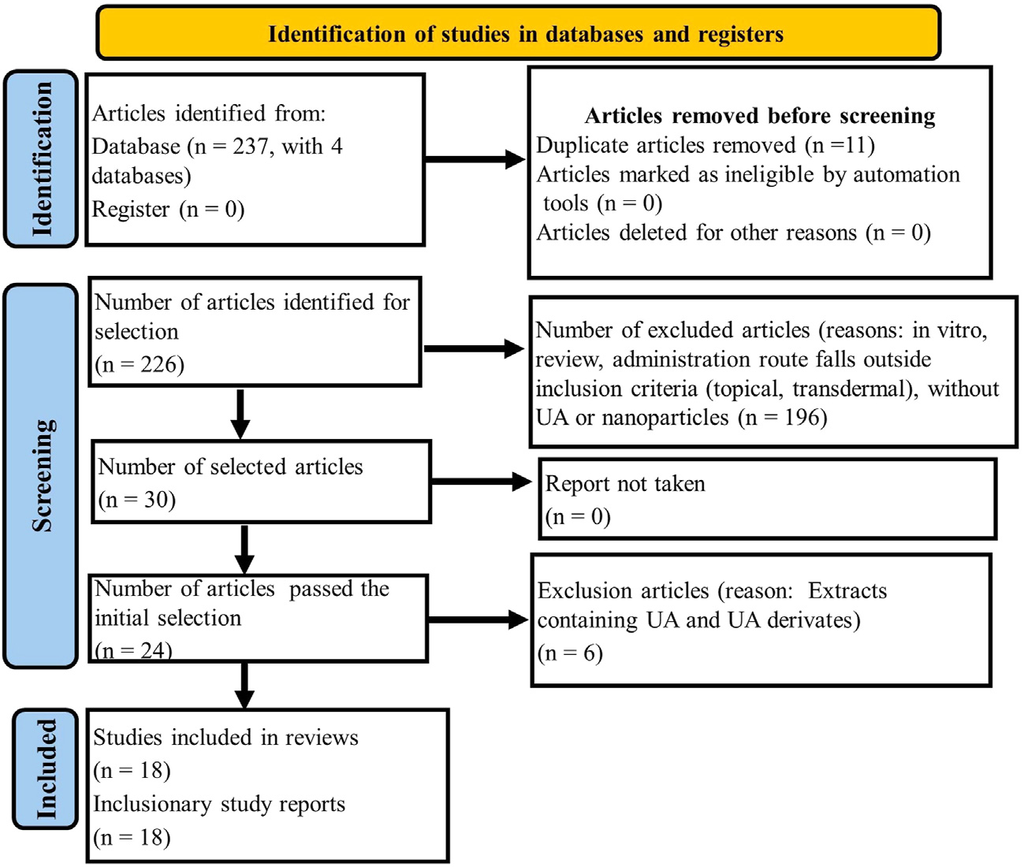

FIGURE 1 | Flow chart of PRISMA method for article identiﬁcation, screening, and selection.

Frontiers in Pharmacology | www.frontiersin.org

December 2021 | Volume 12 | Article 787226

6

Miatmoko et al.

Nanoparticles use for Ursolic Acid

TABLE 2 | The summary of literature reviews for UA-loaded nanoparticles.

No

Code

Carrier type

Formula-tion

Type of

research

Information research

Administra-tion route

Reference

1

Lipo A

Liposomes

Not Available

Phase I

Clinical Trials

Safety Evaluation of Double Dose

and Antitumor Activity of Ursolic

Acid (UAL) Liposomes in Subjects

with Advanced Solid Tumors

including: Non-Hodgkin

Lymphoma (24%), Hodgkin

Lymphoma (24%), Renal

Carcinoma (5%), Hepatocellular

Carcinoma (5%), Breast Cancer

(9%), Lung Cancer (9%), Other

Cancers (19%)

Intravenous 4 h infusion at doses

equivalent to 54, 74, and

96 mg UA/m<sup>2</sup>for 14 consecutive

days

Qian et al.

(2015)

2

Lipo B

Liposomes

Not Available

Phase I

Clinical Trials

Toxicity evaluation of a single dose

of intravenous ursolic acid

liposomes (UAL) in healthy adult

volunteers and patients with

advanced solid tumors including

Non-Hodgkin Lymphoma, Hodgkin

Lymphoma, Renal Carcinoma, and

Hepatocellular Carcinoma

Intravenous (IV) route at doses

equivalent to 11, 22, 37, 56, 74,

and 96, and 130 mg UA/m<sup>2</sup>

administered as a 4 h infusion

Wang et al.

(2013)

3

Lipo C

Liposomes

Not Available

Phase I

Clinical Trials

Toxicity evaluation of Ursolic Acid

Nanoliposome (UANL) in healthy

volunteers and patients with

advanced solid tumors including:

Non-Hodgkin Lymphoma (50%),

Hodgkin Lymphoma (12.5%), Gut

Cancer (12.5%), Hepatocellular

Carcinoma (25%)

Intravenous (IV) route at doses

equivalent to 74 mg/m<sup>2</sup>as a

single dose, 98 mg/m<sup>2</sup>, and

74 mg/m<sup>2</sup>as double doses daily

for 14 days via a 4 h infusion

Zhu et al.

(2013)

4

Lipo D

Liposomes

Hydrophobic components (PC,

Chl, and UA) at a weight ratio of

2:1:0.5; ethanol injection

method

Preclinical or

in vivo study

Tumor inhibition activity and toxicity

studies of UA-PLL-HA in SCC-7

tumor-induced mice

Intravenous (IV) at a dose of

equivalent to 20 mg UA/Kg

mouse for 5 times every 4 days

Poudel et al.

(2020)

5

Lipo E

Liposomes

PEGylated UA Liposomes

composed of SPC, CHOL, and

UA at a weight ratio of 50:8:5,

respectively; ethanol injection

method

Preclinical or

in vivo study

Tumor growth inhibition study and

cytotoxicity of UA PEGylated

liposomes in mice with U14 cervical

carcinoma cells

Intragastric route at a dose of

equivalent to 80 mg UA/kg

mouse twice a day for a total of

14 days

Wang et al.

(2016)

6

Lipo F

Liposomes

Liposomes composed of

hydrophobic components

(SPC, CHOL and UA) at a

weight ratio of 0:6:5; ethanol

injection method

Preclinical or

in vivo study

Tumor growth inhibition and toxicity

studies of CS-UA-L in mice with

U14 cervical carcinoma cells

Intragastric route at a dose of

equivalent to 80 mg UA/Kg

mouse once a day for 14 days

Wang et al.

(2017)

7

G<sup>Lipo</sup>

Liposomes

Lipids-UA (HSPC/Kolesterol/

DSPE-PEG2000/UA � 90/0/5/5

and 90/0/5/10, (molar ratio);

thin ﬁlm hydration method

Preclinical or

in vivo study

Tumor and growth inhibition study

of UA-L in mice with 4T1 tumors

(breast cancer)

Intravenous (IV) route at a dose of

equivalent to 10 mg UA/kg

mouse for 5 times every

other day

Zhang et al.

(2020)

8

Lipo H

Liposomes

Lipid components of FA-UA-L:

DOTAP/CHOL/MPEG-

DSPE2000/FA-PEG-CHEMS at

a molar ratio of 40:55:4, 5:0, 5

(equal to weight ratio of 28;

21,3; 12,6, dan 2, 1 mg). The

ratio of UA to lipid is 1:20 (w/w);

thin ﬁlm hydration method

Preclinical or

in vivo study

Tumor growth inhibition and toxicity

studies of FA-UA/siRNA-L in mice

with human kB cells tumor

Intravenous (IV) injection with the

dose of 4.5 mg/kg for UA and

170 μg/kg for siRNA for 5 times

every other day

Li et al.

(2019)

9

Lipo I

Liposomes

Lipid composition: HSPC/

CHOL/mPEG-DSPE2000/FA-

PEG-CHEMS at molar ratio 63:

32:4.5:0.5 (equal to weights

amount of 48, 12, 13.4, and

5 mg), respectively. The ratio of

UA to lipids is 1:20 (w/w); thin

ﬁlm hydration method

Preclinical or

in vivo study

Efﬁcacy study of FTL-UA for tumor

inhbition in mice with human KB

tumor cells

Intravenous (IV) at a dose of

equivalent to 4.5 mg UA/kg

mouse for 5 times every other

day, which is similar to 23 mg/kg

or 98 mg/m<sup>2</sup>drug administration

Yang et al.

(2014)

10

A<sup>Nano</sup>

Nanospheres

Not available

Preclinical or

in vivo study

Tumor growth inhibition and toxicity

studies of HCPT @F-Pt-PU NPs in

mice with H22 subcutaneous

tumors (liver cancer)

Intravenous (IV) injection at a

dose of equivalent to 10 mg

UA/kg mouse for 5 times every

2 days

Liu et al.

(2021)

(Continued on following page)

Frontiers in Pharmacology | www.frontiersin.org

December 2021 | Volume 12 | Article 787226

7

Miatmoko et al.

Nanoparticles use for Ursolic Acid

encapsulated

drug,

in

the

bilayer

membrane

or

aqueous

intravesicular compartments or the matrix of nanoparticles

(Kulkarni et al., 1995). UA has poor permeability and low water

(Sun et al., 2020), thus causing possibly encapsulated within

membrane bilayer of lipid vesicles. As can be seen in Figure 2B,

the EE of liposomes and nanospheres ranges from 30% to ≥90%,

while the EE of polymeric micelles is not mentioned. This suggests

that drugs are successfully encapsulated in nanoparticles in order to

increase the amount of drugs delivered to the target sites.

Pharmacokinetic Data in Clinical Trials

From the review of pharmacokinetic data relating to clinical trials, it

was found that in Lipo A the average t1/2 of UAL was 4.00–4.58 h, a

low value of t1/2 resulting in its rapid elimination from the blood

circulation as shown by the contents of Table 3. This suggests that

UAL does not accumulate in the body but must be infused

repeatedly to ensure the steady plasma concentration of UA and

further enhance its antitumor effect (Qian et al., 2015). In Lipo B, a

linear relationship exists between Cmax or AUC0→24h or AUC0→∞

and increased doses of UAL, signifying that UAL has a linear

pharmacokinetic proﬁle (Wang et al., 2013). In Lipo C, after

administration of a single IV dose, the total concentration of UA

in all subjects experienced a two-fold decrease. On completion of IV

infusion, the plasma concentration of UA rapidly decreases to one

approximately ten times lower than the peak concentration after

2 hours. The pharmacokinetics proﬁles of UAL are linear and dosage

TABLE 2 | (Continued) The summary of literature reviews for UA-loaded nanoparticles.

No

Code

Carrier type

Formula-tion

Type of

research

Information research

Administra-tion route

Reference

11

B<sup>Nano</sup>

Nanospheres

NP composed of 32 mg

chitosan, 10 mg UA, 30 mg

EDC, and 8 mg NHS. The ratio

of UA to lipids is 1:10 (w/w);

overnight magnetic stirring

method

Preclinical or

in vivo study

Tumor inhibition study of CH-UA-

NPs in mice with H22

subcutaneous tumors (liver cancer)

Oral administration at a dose of

equivalent to 11 mg UA/Kg

mouse once every 2 days for a

total of 8 times

Jin et al.

(2016a)

12

C<sup>Nano</sup>

Nanospheres

NP composed of 32 mg

chitosan, 10 mg UA, 30 mg

EDC, and 8 mg NHS. The ratio

of UA to lipids is 1:10 (w/w);

overnight magnetic stirring

method

Preclinical or

in vivo study

FA-CS-UA-NPs tumor inhibiting

activity study in MCF-7 xenograft

bearing models (breast cancer)

Intraperitoneal (IP) injection at a

dose of equivalent to 12.5 mg

UA/kg mouse once a day for

9 times

Jin et al.

(2016b)

13

D<sup>Nano</sup>

Nanospheres

Not available

Preclinical or

in vivo study

Tumor growth inhibition efﬁcacy

and toxicity studies of UA-LA-ICG

NPs in tumor bearing mice by

murine H22-hepatocarcinoma cells

induced tumor xenograft models

Intravenous (IV) injection at a

dose of 10 mg/kg of UA and

2.5 mg/kg of ICG with 5 min

irradiation at 24 h post injection

Zhao et al.

(2018)

14

E<sup>Nano</sup>

Nanospheres

Prepared by making 3 mg UA

solution in ethanol (1 ml,

6,569 mM) in 10 ml of water.

The ratio of UA and NPs was 1:

10, respectively; solvent

exchange preparation method

Preclinical or

in vivo study

Tumor inhibition efﬁcacy and

toxicity studies of UA NPs in mice

bearing A549 xenograft models

(lung cancer)

Intravenous (IV) injection at a

dose of 8 mg/kg of UA for

21 days

Fan et al.

(2018)

15

F<sup>Nano</sup>

Nanospheres

Not available

Preclinical or

in vivo study

Tumor inhibiting activity and toxicity

studies of UA NPs in H22-induced

mice (Hepatocellular carcinoma)

Intraperitoneal (IP) injection at a

daily dose of 50 mg/kg of UA for

10 days

Zhang et al.

(2015)

16

G<sup>Nano</sup>

Nanospheres

Self-assembly method of

polymer deposition

Preclinical or

in vivo study

Antitumor activity and toxicity

studies of Pec-8PUH NPs in mice

with 4T1 tumors (breast cancer)

Intravenous (IV) injection at a

dose of 10 mg/kg of UA once

every 2 days for 5 times

Liu et al.

(2018)

17

Poli A

Polymeric

Micelles

PM composed of UA (4 mg)

and mPEG2000-PLA2000

(40 mg) at a weight ratio of 1:10;

thin ﬁlm dispersion method

Preclinical or

in vivo study

Antitumor activity and toxicity

studies of UA-PMs in H22-induced

mice (Hepatocellular carcinoma)

Intraperitoneal (IP) injection at a

dose of 50 mg/kg of UA every

2 days for 6 times

Zhou et al.

(2019)

18

Poli B

Polymeric

Micelles

Solvent evaporation method

Preclinical or

in vivo study

Antitumor activity and toxicity

studies of U-SS-M in tumor bearing

MG-63/Osteosarcoma (OS)

Intravenous (IV) injection at a

dose of 11 mg/kg of UA every

3 days for 5 times

Fu et al.

(2021)

Notes: UAL, Ursolic Acid Liposome; UANL, Ursolic Acid Nanoliposome; UA-PLL-HA, Ursolic Acid-Poly-L-Lysine-Hyaluronic Acid; UA-PEGylated, Ursolic Acid-Polietilenglikolisasi; CH-

UA-NPs, Chitosan-Ursolic Acid-Nanoparticles; CS-UA-L, Chitosan- Ursolic Acid-Liposome; CHOL/Chl, Cholesterol; DSPE-PEG2000, 1,2-distearoyl-sn-glycero-3-

phosphoethanolamine-N [methoxy (poly- ethylene glycol) -2000]; DOTAP, 1, 2-dioleoyl-3-trimethylammonium-propane; EDC, Ethyl-(3-3-dimethylaminopropyl) carbondiimide

hydrochloride; FA-CS-UA-NPs, Folate- Chitosan-Ursolic Acid-Nanoparticles; FA-PEG-CHEMS, Folate Polyethylene Glycol Cholesteryl hemisuccinate; FA-UA/siRNA-L, Folate- Ursolic

Acid/Small Interfering RNA-Liposome; F-Pt-PU, Folic Acid-Pectin-Eight-Arm PEG-UA conjugate; FTL-UA, Folate Receptor Targeted Liposome-Ursolic Acid; HCPT @F-Pt-PU NPs,

Hydroxycamptothecin @folic acid-pectin-eight-arm PEG-UA nanoparticle; HSPC, Hydrogenated Soybean Phosphatidyl Choline; mPEG2000-PLA2000, Monomethoxy Polyethylene

Glycol 2000 Poly Lactic Acid 2000; MPEG-DSPE2000, Monomethoxy Polyethylene Glycol 2000-Distearoyl Phosphatidylethanolamine; NHS, N-Hydroxy-Succinimide; PC,

Phosphatidylcholine; Pec-8PUH NPs, pectin-eight-arm polyethylene glycol-ursolic acid/hydrooxycampothecin nanoparticle; SPC, Soybean Phosphatidyl Choline; UA-NPs, Ursolic Acid-

Nanoparticles; UA-LA-ICG NPs, Ursolic Acid- Lactobionic Acid -Indocyanine Green; UA-PMs, Ursolic Acid-Polymer Micelles; U-SS-M, Micelles assembled by PEG-SS-UA (polyethylene

glycol using a disulﬁde bond)

Frontiers in Pharmacology | www.frontiersin.org

December 2021 | Volume 12 | Article 787226

8

Miatmoko et al.

Nanoparticles use for Ursolic Acid

proportional at a range of 37 mg/m<sup>2</sup>to 98 mg/m<sup>2</sup>. No accumulation

of UA was observed following repeated doses of UAL in eight

patients after receiving continuous IV infusion 74 mg/m<sup>2</sup>over a 14-

day period (Zhu et al., 2013).

Pharmacokinetic Data Review on In Vivo

Studies

The pharmacokinetic data on in vivo studies of Lipo E shows that

the highest plasma UA concentration in the PEGylated liposome

treatment group was 19.87 ug/mL, which exceeded that of both

the Ursolic Acid Liposomes (UAL) and Ursolic Acid (UA)

solution groups. In addition, as seen from Table 4, PEG-

modiﬁed liposomes have the longest t1/2, while Cmax

and

AUC in the bloodstream have similar trends. This suggests

that PEGylated UA liposomes may extend the time required

for the drug to circulate in the circulatory system and produce a

slow release effect (Wang et al., 2016).

In Nano A, after administration of a hydrophobic drug,

i.e., hydroxycamptothecin (HCPT), conjugated to folic acid-

pectin-eight-arm PEG-UA (F-Pt-PU) the concentration of UA

and HCPT in plasma decreases slowly, resulting in the longer

circulation period of native UA, which may be due to the breaking

of ester bonds between 8 arm-PEG and UA. The concentration of

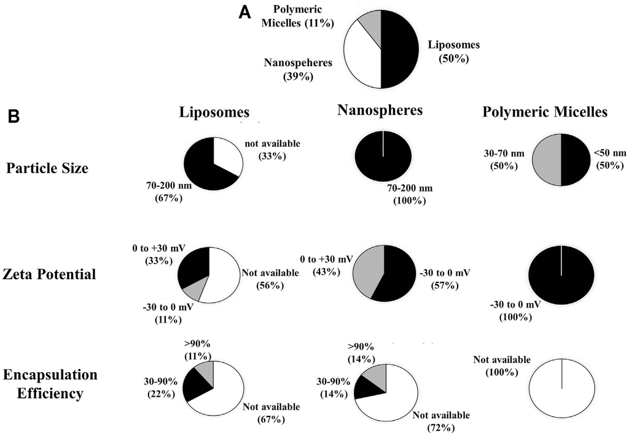

FIGURE 2 | (A) Types of drug carrier extracted from the article review regarding the preclinical and clinical studies of nanoparticle use for UA delivery within cancer

therapy, (B) the physical characteristics of UA-loaded nanoparticles including particle size, zeta potential, and efﬁciency of encapsulation.

TABLE 3 | Pharmacokinetic data from clinical trials of UA-loading nanoparticles.

Parameter

Lipo A

Lipo B

Lipo C

Administration Route

Intravenous

Intravenous

Intravenous

Dose (mg/m<sup>2</sup>)

74 (double dose)

37

74

98

37

74 (single dose)

98

74 (double dose)

t1/2 T1/2(hours)

4.58 ± 2.04

4.59 ± 2.44

4.46 ± 1.41

3.90 ± 2.08

4.59 ± 2.44

4.46 ± 1.41

3.90 ± 2.08

4.58 ± 2.04

Vd (L/m<sup>2</sup>)

NA

NA

NA

NA

58.7 ± 33.0

64.3 ± 17.9

55.4 ± 28.1

88.6 ± 31.8

CL (L/h/m<sup>2</sup>)

NA

8.65 ± 1.09

10.2 ± 1.46

9.94 ± 1.13

8.67 ± 1.07

10.20 ± 1.46

9.94 ± 1.13

14.40 ± 3.94

AUC0−t (ng·h/mL)<

5,172 ± 1,136

4,213 ± 606

7,175 ± 999

9,696 ± 1,134

4,203 ± 588

7,175 ± 999

9,696 ± 1,134

5,172 ± 1,136

AUC0−∞ (ng·h/mL)

5,498 ± 1,525

4,339 ± 574

7,418 ± 1,057

9,971 ± 1,144

4,329 ± 556

7,418 ± 1,057

9,971 ± 1,144

5,498 ± 1,525

MRT0−t (hour)

NA

3.69 ± 0.36

3.93 ± 0.37

3.84 ± 0.34

3.69 ± 0.36

3.93 ± 0.37

3.84 ± 0.34

3.34 ± 0.55

MRT0−∞ (hour)

NA

4.28 ± 0.91

4.56 ± 0.88

4.41 ± 0.95

4.29 ± 0.90

4.56 ± 0.88

4.41 ± 0.95

4.31 ± 1.89

Cmax (ng/ml)

1,589 ± 635

1835 ± 438

2,865 ± 868

3,457 ± 856

1835 ± 438

2,865 ± 868

3,457 ± 856

1,589 ± 635

Tmax (hour)

NA

4.03 ± 0.04

4.02 ± 0.04

4.0 ± 0.00

4.03 ± 0.04

4.02 ± 0.04

4.00 ± 0.00

3.00 ± 1.41

Notes: t1/2, half-life time; Vd , distribution volume; CL, clearance; AUC, area under curve of concentration vs time; MRT, mean retention time; Cmax , maximum plasma concentration; Tmax ,

time required to reach maximum plasma concentration.

Frontiers in Pharmacology | www.frontiersin.org

December 2021 | Volume 12 | Article 787226

9

Miatmoko et al.

Nanoparticles use for Ursolic Acid

NP HCPT@F-Pt-PU in the bloodstream, still detectable at 80 h, is

higher than that of native UA (7 h) and HCPT (8 h). The

concentration of NP HCPT @F-Pt-PU in plasma is higher

than that of np F-Pt-PU, possibly because the conjugation of

HCPT into polymers increases the strength of the hydrophobic

bonds in the particle cores, thereby reducing the hydrolysis rate of

nanoparticles (Liu et al., 2021).

In Nano G, UA blood circulation in pectin-eight-arm polyethylene

glycol-ursolic acid/hydrooxycampothecin nanoparticles (NP Pec-

8PUH) at 80 h can be maintained at a higher concentration in

plasma, while native UA and HCPT rapidly disappear from

plasma. The half-life of UA blood circulation in NP Pec-8PUH is

8.7 h which is 7.3 times longer than in native UA (Liu et al., 2018).

In Poly B, polymeric drug conjugates are synthesized by

conjugating UA into polyethylene glycol using disulﬁde bonds

(U-SS-M), while UA is eliminated relatively slowly and maintained

at high concentrations in plasma for up to 48 h after administration.

U-SS-M exhibits a similar pattern of biodistribution and accumulates

mainly in the liver and kidneys before being subsequently eliminated

by these organs. In tumor tissue, the concentration of UA decreases

over time, although the amount delivered by the polymer-drug

conjugate gradually increases. The concentration of U-SS-M in

tumor tissue is signiﬁcantly higher than that of native UA at both

6 and 12 h after administration (Fu et al., 2021).

Recapitulation of Pre-Clinical and Clinical

Research Relating to UA Nanoparticles

The results indicate that the available articles which discuss pre-

clinical/in vivo trials amounted of 83%, including the use of

nanoparticle carrier types of nanospheres (47%), liposomes

(40%), and polymeric micelles (13%). As for those that

discussed clinical trials (17%), as seen in Figure 3A–C, these

featured only the use of liposomes (100%). Clinical trials are still

being conducted in phase 1, indicating that they remain at the

stage of evaluating dose levels, acute toxicity, and drug

distribution in humans (Valcourt et al., 2020).

In vivo Anti-Cancer Efﬁcacy of

Nanoparticles Containing UA

Analysis of Tumor Tissue Histopathology

The anticancer effectiveness of nanoparticles containing UA

compared to negative control and free UA are shown to have

a signiﬁcant effect on tumor growth inhibition as shown in

Table 5.

Comparative Analysis of Tumor Growth Inhibition

The results indicate that the normal tumor volume when

compared to administration of UA-loaded liposomes (Lipo D,

E, F, G, H, I), nanospheres (Nano A, B, D, E, F, G) and polymeric

micelles (Poly A) decreased in relative tumor volume by

approximately 2.0–21.2 times. The tumor volume of native

UA compared to the administration of UA liposomes (Lipo D,

E, F, G, H, I), nanospheres (Nano A, D, E, F, G) and polymeric

micelle (Poly A) showed a relative reduction in tumor volume of

about 1.6–15.9 times lower than that of the native UA group, as

presented in Figure 5A. This suggests that nanoparticles can

improve UA effectiveness in inhibiting expansions in tumor

volume.

The relative tumor weight analysis results relating to groups

treated with UA liposomes (Lipo D, E, F), nanospheres (Nano C,

E) and polymeric micelles (Poly A,B) indicated a relative

reduction in tumor weight approximately 1.9–5.3 times that of

the negative control group. Tumor weight in the native UA group

compared to that of groups administered with UA liposomes

(Lipo D, E, F), nanospheres (Nano C,E) and polymeric micelles

(Poly A,B) showed a relative reduction of about 1.6-3.2x, as

shown in Figure 5B. This suggests that nanoparticles may

increase the effectiveness of UA in inhibiting tumor growth

resulted in reduction of tumor weight.

The relative inhibition rate analysis results indicate that the

administration of UA liposomes (Lipo E, F), nanospheres (Nano

A) and polymeric micelles (Poly B) produces an increase in the

TABLE 4 | Pharmacokinetic data summary of preclinical studies of nanoparticles

containing UA.

Parameter

Lipo E

Nano A

Nano G

Poli B

Administration route

intragastric

intravenous

intravenous

intravenous

UA dose (mg/kg)

80

10

10

11

T1/2 (hour)

8.6

8.3 and 10

8.7

4.9 and 5.2

AUC (µg.h/ml)

134.061

NA

NA

NA

Cmax (µg/ml)

19.87

NA

NA

NA

Tmax (hour)

NA

80

80

48

Notes: T1/2, half-life time; AUC, area under curve of concentration versus time; Cmax ,

maximum plasma concentration; Tmax , time required to reach maximum plasma

concentration.

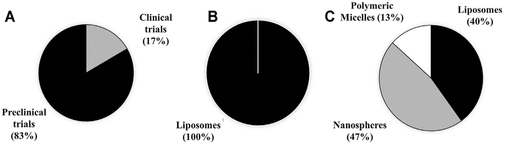

FIGURE 3 | Research recapitulation of (A) clincial and preclinical studies, (B) types of nanoparticle use in clinical trials, (C) and pre-clinical trials.

Frontiers in Pharmacology | www.frontiersin.org

December 2021 | Volume 12 | Article 787226

10

Miatmoko et al.

Nanoparticles use for Ursolic Acid

relative

tumor

inhibition

rate

of

approximately

1.9-3.4x

compared to the native UA group. Of the three types of drug

carriers, liposomes (Lipo F) experienced the highest relative

inhibition rate increase of 3.4x the native UA group, as seen

in Figure 4A. This suggests that nanoparticles may increase the

effectiveness of UA in inhibiting tumor growth.

Analysis of Survival Rate

when compared to that of the negative control group, as seen in

Figure 4B. This suggests that nanoparticles may increase the

effectiveness of UA associated with improved survival rate.

The increased anti-tumor activity observed from the volume

and weight of the tumor was associated with necrosis in the tumor

tissues caused by large dose exposures of UA reaching cancer cells

due to the increased permeability of small nanoparticles with high

drug loading due to the EPR effect. Furthermore, the drug will be

released into the extracellular and/or intracellular matrix. In the

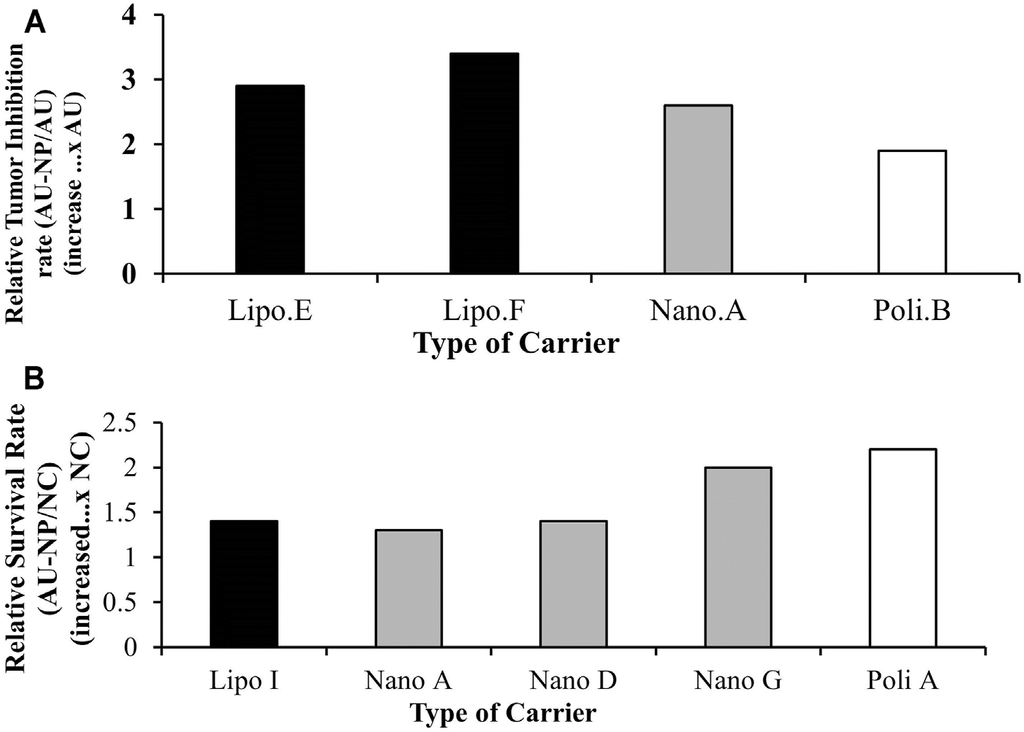

FIGURE 4 | (A) Relative tumor growth inhibition rate of animal models treated with nanoparticles loading UA compared to native UA treatment groups, (B) Relative

survival rate of animal models treated with UA-loaded nanoparticles compared to the negative control.

TABLE 5 | Tissue histopathology of liver cancer after administration of negative control, native UA and nanoparticles containing UA.

Code

Tissue histopathology

Negative control

Free UA

Nanoparticles containing UA

Lipo E

It features no hemorrhagic or necrosis phenomena

and the cell is round or polygonal

Tumor cells and angiogenesis occur in native UA

solution and conventional UA liposomes treatment

groups, which become rare with slight necrosis

The tumor cells of the UA liposome with

polyethylene glycols (PEGylated UA Liposome)

group undergo severe necrosis, the nucleus/pulp

ratio is signiﬁcantly reduced, and apoptosis occurs

due to a large number of scattered single tumor cells

Lipo F

The nucleus size and tumor cell shape are irregular.

The tumor cells have clear cellular morphology and

chromatin indicating that the tumor cells are

growing quickly

A limited shrinkage and fragmentation of the

nucleus indicates a low rate of tumor cell necrosis

Most tumor tissue cells in the group treated with

Chitosan-Ursolic Acid-Liposomes (CS-UA-L)

undergo apoptosis or necrosis, indicating good

potential for killing cancer cells

Nano B

There are numerous sinusoids and small blood

vessels ﬁlled with blood (indicated by the arrow)

spreading through the hepatocellular carcinoma

trabeculae

Not available

Several sinusoid liver or blood vessels can be

observed in Chitosan-Ursolic Acid-Nanoparticle

(CH-UA-NP) group with the exception of liver

sinusoid dysplasia. Massive necrotic tissue can still

be observed in hepatocellular carcinoma

Poli A

Tumor necrosis is undeﬁned in the saline treatment

group

Tumor cells and angiogenesis become rare with

little necrosis

Most cancer cells in the high-dose Ursolic Acid-

Polymer Micelles (UA-PMs) group at 100 mg/kg

showed a high degree of H22 cell necrosis

11

Miatmoko et al.

Nanoparticles use for Ursolic Acid

extracellular ﬂuids, the drug will leak from nanoparticles and

subsequently diffuse into cancer cells, while in intracellular ﬂuids

nanoparticles will experience endocytosis and the matrix will be

destroyed in the endosome and release free drugs which then

diffuse into the cytoplasm and nucleus subsequently causing cell

necrosis. These results show that the use of nanoparticles as

carriers within anticancer drug delivery can increase the in vivo

survival rate.

Other studies have suggested that when nanoparticles such as

liposomes interact with cells, drug delivery and diffusion into

target cells can occur in several ways. Liposomes can penetrate the

tumor tissue matrix resulting in degradation of carrier lipids by

enzymes, such as lipase, or by mechanical strain inducing release

of active substances into the extracellular ﬂuid. This process

induces drug diffusion into cell membranes culminating in

cytoplasm and nucleus delivery. However, the latter process

cannot easily be achieved by the use of hydrophilic drugs.

Secondly, liposome membranes will fuse with those of the

target cell leading to the release of liposomes directly into the

cytoplasm. The third and most frequent method is that of

receptor-mediated endocytosis. This process involves only

vesicles with a maximum diameter of 150 nm and active

substances demonstrating signiﬁcant stability in such an acidic

lysosome

environment

where

liposomes

are

metabolized

enzymatically. Phagocytosis may also ensue but involving large

size nanoparticles affected by specialized immune system cells,

such as macrophages, monocytes, and Kupffer cells. This process

may eliminate the nanoparticles from the circulatory system

(Bozzuto and Molinari, 2015).

The survival rate of liposomes is higher than that of other

nanoparticles indicating the stability of the system in the

blood circulation which ensures that the trapped drug is

carried by the nanoparticles for further release into the

cancer

cells.

In

addition,

because

of

the

biomimetic

property

of

liposome

components

that

resemble

phospholipid cell membranes it is easier for them to be

absorbed by the cell.

In vivo Toxicity Studies of Nanoparticles

Containing UA

Pre-Clinical Toxicity Based on the Analysis of Relative

Body Weight

From the results of relative body weight calculations

contained in Table 6, no signiﬁcant differences existed in

the

weight

of

the

mice,

proving

that

nanoparticle

administration neither caused side effects nor produced

symptoms of toxicity (Poudel et al., 2020; Liu et al., 2021;

Fu et al., 2021). This result is also supported by other toxicity

data presented in Table 7, which shows that there was no

clear cell damage and no morphological changes in the major

organs i.e. heart, liver, spleen, lungs, and kidneys. However,

of UA nanoparticles when compared to native UA (Zhang

et al., 2015; Zhao et al., 2018). This suggested that UA

duration (Li et al., 2019).

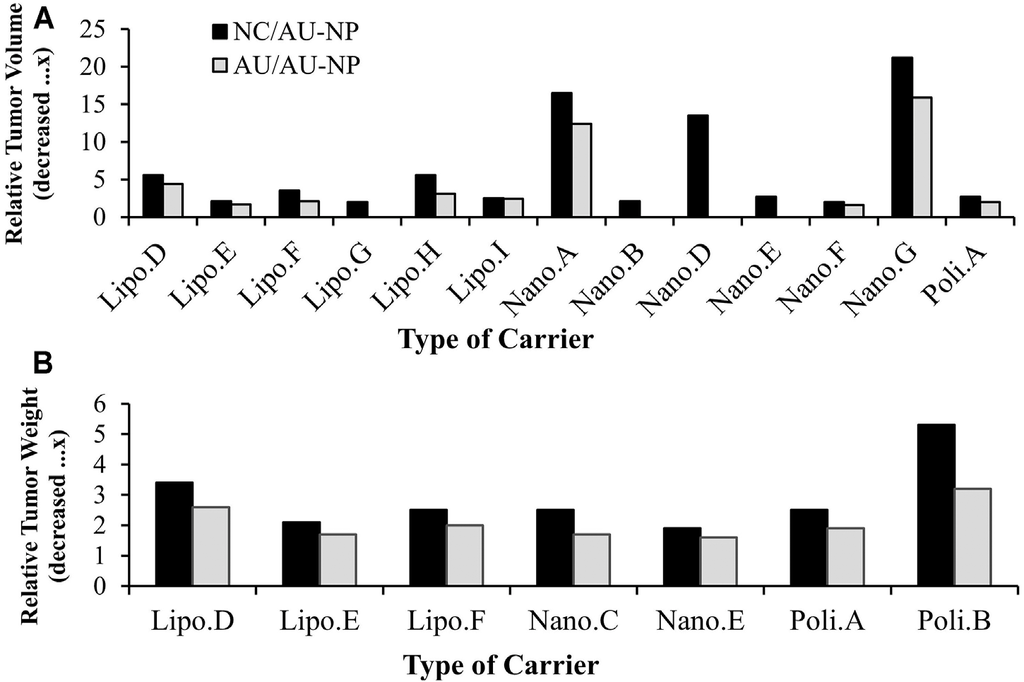

treatment groups (grey bars).

12

Miatmoko et al.

Nanoparticles use for Ursolic Acid

Safety Aspects of the Use of Nanoparticles

Containing UA Based on the Clinical Trials

Toxicity Based on Clinical Laboratory Parameters

The content of the graphs contained in Figure 6A, conﬁrm an

increase in levels of AST, ALT, GGT, TG, DBIL, and TBIL

after UA liposome (Lipo A, B, C) administration occurred. It

can also be seen that Dose Limiting Toxicity (DLT) related to

hepatotoxicity, which was monitored for substantial side

effect parameters, was at a moderate level (Valcourt et al.,

2020).

In Lipo A, an increase in levels of AST (5%), ALT (5%),

GGT (14%), TG (5%) was observed in 21 subjects who

received doses of 56, 74, and 98 mg/m<sup>2</sup>. In Lipo B, elevated

levels of AST (13%), ALT (13%), GGT (15%), TG (8%), DBIL

(5%) and TBIL (8%) were recorded in 39 subjects receiving

doses of 11, 22, 37, 56, 74, 98, and 130 mg/m<sup>2</sup>. In Lipo C, there

was an increase in AST (4%), ALT (4%), GGT (2%), TG (9%),

and TBIL (4%) levels observed in 24 subjects who received

doses of 74 mg/m<sup>2</sup>as a single dose and 98 and 74 mg/m<sup>2</sup>as

multiple doses.

Clinical Toxicity Based on the Occurences of Adverse

Events

According to the data contained in Figure 6B, three subjects (14%)

treated with a dose of 56 mg/m<sup>2</sup>of Lipo A experienced a mild fever

but recovered after 2 hours without receiving treatment. Moreover,

three subjects (14%) treated with sequential doses of 56, 74, and

98 mg/m<sup>2</sup>of Lipo A experienced an increase in GGT, two subjects

(10%) administered with doses of 56 and 74 mg/m<sup>2</sup>of Lipo A

experienced

abdominal

distension,

and

one

patient

(5%)

experienced a rise in ALT levels. Other mild symptoms

included increased AST and TG, pruritus, arthralgia, and

hypokalemia. The most common adverse conditions included

fever, increased GGT, and ﬂatulence. These results indicated

that a 4-h intravenous administration of Lipo A was tolerable

and safe if a timetable of three doses per day for 14 consecutive days

TABLE 6 | The relative body weight of animal models treated with UA-loaded nanoparticles compared to negative control and native UA-treatment groups.

Code

Toxicity

Lipo H

ALT and AST levels were signiﬁcantly higher following an injection of FA-UA/siRNA-L compared to that of saline solution. The

AST/ALT ratio of the FA-UA/siRNA-L group was signiﬁcantly lower than that of the saline group. These results suggest that

liver toxicity caused by liposomes produces mild, temporary liver toxicity

Nano A

The number of rat WBCs in the NP HCPT@F-Pt-PU treatment group increased more rapidly than in the native UA group

which suggests that folate-targeted pectin delivery systems may prevent serious hematological toxicity

Nano D

There was no obvious cell damage or morphological changes in the major organs i.e., heart, liver, spleen, lungs, and kidneys

in the NP UA-LA-ICG treatment group members compared to those of the negative control group

Nano E

ALT levels in mice treated with UA-NP were signiﬁcantly lower than in the CCl4 group members, but there were no changes

in the native UA- treatment group. In addition, AST levels in the UA-NP treatment group were also signiﬁcantly lower

compared to the CCl4 group and the native UA-treatment groups

Nano F

The native UA group experienced necropsy in the central section of the tumor tissue. These results partly suggest that native

UA causes more toxicity than UA-NP. Meanwhile, H&E staining indicated that there were no obvious abnormalities or

inﬂammatory lesions in any of the ﬁve organs, i.e., heart, liver, spleen, lungs, kidneys for the UA-NP treatment group when

compared to their negative control and native UA counterparts

Nano G

Rats treated with the Pec-8PUH-NPs group did not experience any signiﬁcant reduction in WBC counts as an indicator of

hematotoxicity suggesting that the use of nanoparticles might prevent hematological toxicity

TABLE 7 | Recapitulation of other preclinical toxicities.

Relative body weight

Code

Results

NC/AU-NP

AU/AU-NP

Lipo D

Decreased by 1.2x normal value (Not signiﬁcant)

Increased by 1.0x AU value (Not signiﬁcant)

Lipo E

Decreased by 1.1x normal value (Not signiﬁcant)

Increased by 1.0x AU value (Not signiﬁcant)

Lipo F

Decreased by 1.2x normal value (Not signiﬁcant)

Decreased by 1.0x AU value (Not signiﬁcant)

Lipo G

There is no obvious difference

Not available

Lipo H

Decreased by 1.0x normal value (Not signiﬁcant)

There is no obvious difference

Nano A

There is no obvious difference

There is no obvious difference

Nano D

There is no obvious difference

There is no obvious difference

Nano E

There is no obvious difference

There is no obvious difference

Nano F

Decreased by 1.0x normal value (Not signiﬁcant)

Increased by 0.9x AU value (Not signiﬁcant)

Nano G

There is no obvious difference

There is no obvious difference

Poli A

Decreased by 1.1x normal value (Not signiﬁcant)

Decreased by 1.0x AU value (Not signiﬁcant)

Poli B

There is no obvious difference

There is no obvious difference

13

Miatmoko et al.

Nanoparticles use for Ursolic Acid

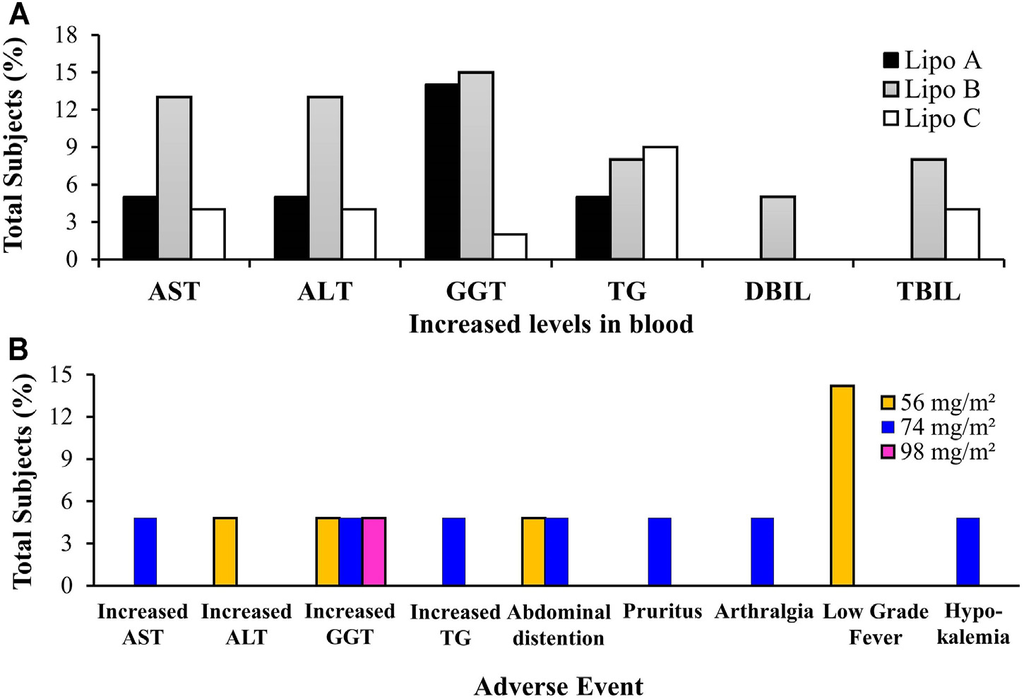

FIGURE 6 | (A) Total subjects with increasing blood marker levels on clinical trials of Lipo A, Lipo B, and Lipo C, (B) Adverse events of Lipo A during phase I clinical

trials. Notes: AST, Alanine Aminotransferase/SGPT (serum glutamic pyruvic transaminase); ALT, Aspartate Aminotransferase/SGOT (serum glutamic oxaloacetic

transaminase); GGT, Gamma Glutamyl Transpeptidase; TG, Triglycerides; DBIL, Direct Bilirubin; TBIL, Total Bilirubin.

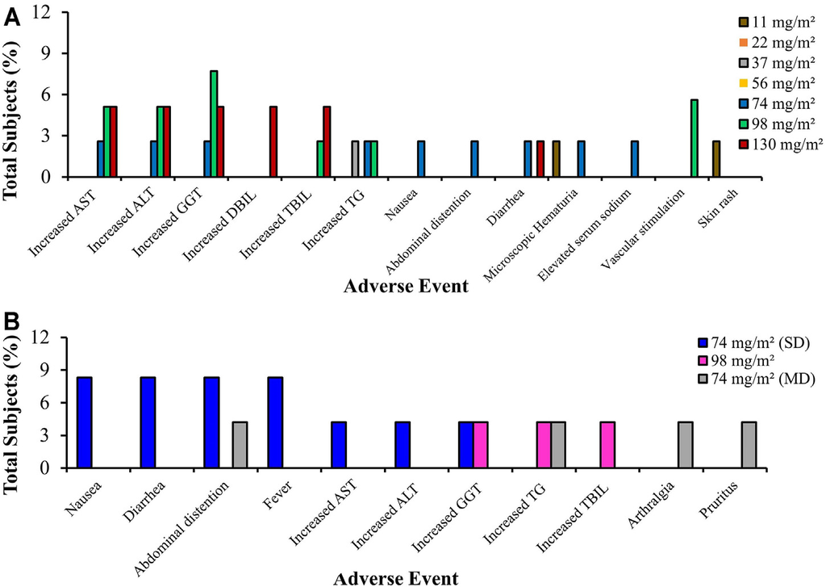

FIGURE 7 | Total subjects with adverse events of (A) Lipo B, and (B) Lipo C in phase I clinical trials. AST, Alanine Aminotransferase/SGPT (serum glutamic pyruvic

transaminase); ALT, Aspartate Aminotransferase/SGOT (serum glutamic oxaloacetic transaminase); GGT, Gamma Glutamyl Transpeptidase; DBIL, Direct Bilirubin;

TBIL, Total Bilirubin; TG, Triglycerides

14

Miatmoko et al.

Nanoparticles use for Ursolic Acid

followed by a break lasting 7 days within each 21-days cycle was

adhered to. Therefore, a 98 mg/m<sup>2</sup>dose of Lipo A is the

recommended dose for phase II trials (Qian et al., 2015).

In addition, from the contents of Figure 7A, it can be seen

that one patient treated with a 11 mg/m<sup>2</sup>dose experienced a

ﬁrst degree skin rash which healed untreated after 3 days. In

addition, two patients who had been administered with a

98 mg/m<sup>2</sup>

dose

experienced

vascular

stimulation.

First

degree

microscopic

hematuria

was

observed

in

subjects (7.7%) suffering from hepatoma malignancy who

had

received

11

doses

of

11,

74,

and

130 mg/m<sup>2</sup>,

respectively. However, these side effects disappeared after

3 days without any treatment being administered. Elevated

levels of AST, ALT, GGT, DBIL, and TBIL were observed in

several subjects receiving doses of 74, 98, and 130 mg/m<sup>2</sup>. Dose

Limiting Toxicity (DLT) resulted in hepatotoxicity: two

subjects

(5.1%)

experienced

an

increase

in

AST,

four

subjects (10.3%) an increase in ALT, one subject (2.6%) an

increase in GGT, and one subject (2.6%) an increase in DBIL.

Diarrhea (2.6%) constitutes another DLT. Other drug-related

side effects included nausea reported by one subject (2.6%),

abdominal distension observed in another (2.6%), vascular

stimulation occurred in two subjects (5.1%), while elevated TG

was reported in three subjects (7.7%). Other reported adverse

events included one subject (2.6%) suffering a skin rash and

another (2.6%) experiencing higher serum sodium levels. At a

dose of 74 mg/m<sup>2</sup>, one of six subjects experienced DLT, which

is a form of non-hematological toxicity, including increased

AST/ALT and diarrhea. At a dose of 98 mg/m<sup>2</sup>, one of the

eleven subjects experienced DLT, i.e., non-hematological

toxicity

including

increased

ALT/GGT).

At

a

dose

of

130 mg/m<sup>2</sup>, two thirds of the subjects experienced DLT

(increased ALT, AST, and DBIL). Therefore, the increased

dosage was suspended and MTD was conﬁrmed to be 98 mg/

m<sup>2</sup>.

Double

administration

of

trial

doses

of

UAL

From the graph in Figure 7B, it is clear that all subjects in the

study tolerated the Lipo C treatment. Most adverse events varying

from mild to moderate related to Lipo C, which is Ursolic Acid

Nanoliposome (UANL), were non-dose dependent. The most

commonly

observed

adverse

events

included

abdominal

distension, nausea, and diarrhea. The adverse events after a

14-days

continuous

infusion

of

UANL

comprised

skin

pruritus, arthrisgia, and increased triglycerides levels. UANL

has minimal toxic effects. The limiting toxicity of UANL dose

is hepatotoxicity. In this study, intravenous UANL infusions were

well tolerated both by healthy volunteers and patients with

advanced tumors (Zhu et al., 2013).

Based on the review analysis, only three articles which focused

on liposomes as the drug carrier discussed clinical trials of UA.

Although UA is classiﬁed as a BCS class IV drug, its permeability

and solubility can be enhanced with the use of liposomes. It is

related to the natural phase properties of the liposomal

membrane that signiﬁcantly affect permeability, aggregation,

protein binding and liposome fusion. Membrane permeability

largely depends on lipid components. Lipids that contain

saturated chains or do not have carbon double bonds are

more stable because they demonstrate greater resistance to

oxidation. Lipid bilayer and liposome membranes possess a

good lipid-packing order or gel phase below the lipid phase

transition temperature (Tc), where the temperature is in a

balanced proportion in the two phases. The ﬂuidity of the

lipid bilayer can be controlled by the selection and combined

use of lipids, as the various Tcs depend on the length and origin

sources (saturated or unsaturated) of fatty acid chains. For

example,

the

incorporation

of

cholesterol

at

low

concentrations into the lipid bilayer leads to increased trans-

membrane permeability, where the incorporation of large

amounts (>30 mol%) of cholesterol can reduce the transition

phase and decrease membrane permeability at higher Tc

temperatures (Corvera et al., 1992). Liposome permeability is

related to the rate of solute diffusion through the lipid bilayer. The

liposome membrane will achieve the highest permeability in the

transition temperature phase, while its permeability is lower in gel

form than in the ﬂuid phase. The temperature of the bilayer phase

transition is determined by the composition of the liposome. In

the transition temperature phase, the permeability of liposomes

to molecules such as protons and water increases (Koda et al.,

2008; Yoshimoto et al., 2013; Hansen et al., 2015). In addition, the

in vivo biodistribution and disposition of liposomes varies

depending on the composition of the lipids, particle size,

potential charge and degree of steric surface/hydration. In

addition, the administration route may affect the in vivo

disposition of liposomes. During intravenous administration,

liposomes

usually

interact

with

serum

proteins

and

are

absorbed by RES cells, thus accumulating in the liver or spleen

(Sercombe et al., 2015).

The development of nanoparticles for drug delivery, one of

which is Doxil<sup>®</sup>(Doxorubicin HCl liposome injection), the ﬁrst

nanoliposomal drug approved by FDA in 1995, was based on

three principles: 1) prolonging drug circulation time and RES

avoidance due to the PEGylation of nanoliposomes; 2) higher

stable loading of doxorubicin driven by the transmembrane

ammonium sulfate gradient which also allows the re-release of

the drug in tumors; and 3) having lipid bilayer liposomes in a

“liquid ordered” phase consisting of phosphatidylcholine with a

high melting temperature (Tm � 53 <sup>°</sup>C), and which largely use

cholesterol as a membrane stabilisator (Barenholz, 2012). In

addition, various drug formulas in liposomes have received

approval to be marketed and are widely used in clinical

settings

including

Myocet®

(Elan

Pharmaceuticals

Inc.,

Princeton,

NJ,

United

States

of

America).

This

is

an

encapsulation of doxorubicin in liposomes (Swenson et al.,

2001; Chastagner et al., 2015); Daunoxome<sup>®</sup>(Gilead Sciences),

daunorubicin

formulated

into

liposomes

(Forssen,

1997;

Dawidczyk et al., 2014); Marqibo<sup>®</sup>non-PEGylated liposomal

vincristine developed in 2012 as a therapy for various cancers

including lymphoma, brain, leukemia, or melanoma (Silverman

and Deitcher, 2012); Onivyde<sup>®</sup>MM-398, which is a PEGylated

liposomal irinotecan developed in 2015 as a drug to treat

metastatic pancreatic cancer (Zhang, 2016), and many other

forms of cancer (Ventola, 2017; Anselmo and Mitragotri,

2019). Various developments of the liposome delivery system

15

Miatmoko et al.

Nanoparticles use for Ursolic Acid

indicated

that

liposomes

possess

non-toxic,

ﬂexible,

biocompatible, and biodegradable properties that can enhance

the therapeutic effects, safety, and efﬁcacy of various anticancer

drugs (Akbarzadeh et al., 2013).

As

for

the

development

of

cisplatin

therapy,

which

incorporates the use of an anticancer drug, this involves a

polymeric micelle delivery system. Polymeric micelles were

prepared through the formation of a metal-polymer complex

between

cisplatin

(CDDP)

and

poly-(ethylene

glycol)-

poly(glutamic acid) block copolymers. Cisplatin polymeric

micelles (CDDP/m) are 28 nm in size with the ability to

distribute themselves through narrow spaces such as blood

vessels in pancreatic tissue. These micelles undergo lengthy

blood circulation and accumulate effectively in solid tumors of

Lewis lung carcinoma cells. However, because they are produced

synthetically,

the

toxicity

and

safety

aspects

as

well

as

manufacturing

production

scale

constitute

extremely

important issues (Plummer et al., 2011).

Abraxane<sup>®</sup>, a paclitaxel albumin-bound nanoparticle with a

particle size of ∼130 nm which received FDA approval in 2005 for

the treatment of metastatic breast cancer succesfully reduces

toxicities in comparison to Taxol<sup>®</sup>. Moreover, it enables a

complete dose to be administered within 30 min without the

need for any pre-treatment. Nevertheless, the mechanism of

Abraxane<sup>®</sup>in improving survival rate and overcoming P-GP-

mediated drug resistance remains unclear (Ma and Mumper,

2013).

The ﬁndings of this scoping review suggest that liposomes

provide

more

comprehensive

data

than

other

forms

studies

of

anticancer

effectiveness

assessed

using

several

parameters such as increasing relative survival rate; more

robust tumor growth inhibition (increasing relative inhibition

rate, decreasing relative tumor weight, and reducing tumor

volume); and improvements in tumor tissue histopathology. In

addition, in vivo studies related to safety were also evaluated

employing several parameters, i.e., weight loss, and other toxicity

healthy volunteers and patients with advanced tumors.

drug

delivery.

The

components

of

the

nanoparticle

formulation

would

greatly

affect

the

characteristics of the nanoparticles including particle size,

potential charges, stealth and biomimetic properties, and

others, which are closely related to drug delivery to cancer

tissue, due to the Enhanced Permeation and Retention (EPR)

effects. In addition, in vivo analysis of different types of cancer,

where each type of cancer cell has different biological

properties, also requires an in-depth study to provide data

on supporting the effectiveness of drug delivery to target

cancerous tissues. Moreover, the route of administration,

dose, and frequency of drug administration related to the

physicochemical properties and pharmacokinetic proﬁle of

the drug also greatly affect the systemic bioavailability and

effective drug amount capable of reaching cancer tissue as the

target of drug delivery. All these aspects provide important

views for comprehensive study of the drug delivery system in

cancer therapy.

CONCLUSION

Based on the scoping review of the relevant literature, it can be

concluded that UA loaded into nanoparticles is effective as a form

of anticancer therapy. Pre-clinical trials conﬁrm that it increases

the relative survival rate; tumor resistance (increasing the relative

inhibition

tumor

volume);

and

improves

tumor

tissue

histopathology. In addition, UA-loaded nanoparticles have

been

proven

safe

for

anticancer

therapy

based

on

the

evaluation of weight loss and other toxicity (decreased AST/

ALT). The results from the last 10-years analysis have indicated

that, compared to nanospheres and polymeric micelles, liposomes

have been assessed as more effective and safer during more

comprehensive pre-clinical and clinical trials. This ﬁnding

highlights the potential for liposomes to be further developed

as a means of delivering UA as an anticancer therapy.

AUTHOR CONTRIBUTIONS

AM: 1) conception and design of the work, data acquisition,

data analysis and interpretation; 2) critically revising the

article for important intellectual content; 3) Final approval

of the version to be published; 4) Agreement to be accountable

for all aspects of the work in ensuring that questions related to

the accuracy or integrity of the work are appropriately

investigated and resolved.

EM:

1) data acquisition;

2)

Drafting the article; 3) Final approval of the version to be

published; 4) Agreement to be accountable for all aspects of the

work in ensuring that questions related to the accuracy or

integrity of the work are appropriately investigated and

resolved. RS: 1) data analysis and interpretation; 2) Final

approval of the version to be published; 3) Agreement to be

accountable for all aspects of the work in ensuring that

questions related to the accuracy or integrity of the work

are appropriately investigated and resolved. EH: 1) data

analysis and interpretation; 2) Final approval of the version

to be published; 3) Agreement to be accountable for all aspects

of the work in ensuring that questions related to the accuracy

or integrity of the work are appropriately investigated.

FUNDING

This study was supported by a Preliminary Research on

Excellence in Higher Education Institutions (Penelitian Dasar

Unggulan Perguruan Tinggi, PDUPT) Grant No. 8/E1/KPT/

2021, No. 4/E1/KP.PTNBH/2021, and No. 385/UN3.15PT/

2021 provided by the Ministry of Research and Technology-

National Research and Innovation Agency of Republic of

Indonesia.

16

Miatmoko et al.

Nanoparticles use for Ursolic Acid

REFERENCES

Akbarzadeh, A., Rezaei-Sadabady, R., Davaran, S., Joo, S. W., Zarghami, N.,

Hanifehpour, Y., et al. (2013). Liposome: Classiﬁcation, Preparation, and

Applications. Nanoscale Res. Lett. 8 (1), 102. doi:10.1186/1556-276X-

8-102

Ali, S. A., Ibrahim, N. A., Mohammed, M. M. D., El-Hawary, S., and Refaat, E. A.

(2019). The Potential Chemo Preventive Effect of Ursolic Acid Isolated from

Paulownia Tomentosa, against N-Diethylnitrosamine: Initiated and Promoted

Hepatocarcinogenesis.

Heliyon

5

(5),

e01769.

doi:10.1016/

j.heliyon.2019.e01769

Alves, R. F., Favaro, M. T. P., Balbino, T. A., de Toledo, M. A. S., de la Torre, L. G.,

and Azzoni, A. R. (2017). Recombinant Protein-Based Nanocarriers and Their

Association

with

Cationic

Liposomes:

Characterization

and

In

Vitro

Evaluation. Colloids Surf. A: Physicochemical Eng. Aspects 513, 1–10.

doi:10.1016/j.colsurfa.2016.11.019

Anselmo, A. C., and Mitragotri, S. (2019). Nanoparticles in the Clinic: An Update.

Bioeng. Transl Med. 4 (3), e10143–16. doi:10.1002/btm2.10143

Baldim, I., Oliveira, W. P., Kadian, V., Rao, R., Yadav, N., Mahant, S., et al. (2020).

Natural Ergot Alkaloids in Ocular Pharmacotherapy: Known Molecules for

Novel Nanoparticle-Based Delivery Systems. Biomolecules 10 (7), 1–21.

doi:10.3390/biom10070980

Barenholz, Y. (2012). Doxil®--the First FDA-Approved Nano-Drug: Lessons

Learned. J. Control. Release 160 (2), 117–134. doi:10.1016/j.jconrel.2012.03.020

Biopharmaceutical,

B.

(2011).

Classiﬁcation

System

and

Formulation

Development. Part. Sci. 9, 1–4.

Bozzuto, G., and Molinari, A. (2015). Liposomes as Nanomedical Devices. Int.

J. Nanomedicine 10, 975–999. doi:10.2147/IJN.S68861

Cabral, H., Matsumoto, Y., Mizuno, K., Chen, Q., Murakami, M., Kimura, M., et al.

(2011). Accumulation of Sub-100 Nm Polymeric Micelles in Poorly Permeable

Tumours Depends on Size. Nat. Nanotechnol 6 (12), 815–823. doi:10.1038/

nnano.2011.166

Chastagner, P., Devictor, B., Geoerger, B., Aerts, I., Leblond, P., Frappaz, D., et al.

(2015). Phase I Study of Non-pegylated Liposomal Doxorubicin in Children

with Recurrent/refractory High-Grade Glioma. Cancer Chemother. Pharmacol.

76 (2), 425–432. doi:10.1007/s00280-015-2781-0

Chen, J., Ping, Q. N., Guo, J. X., Chu, X. Z., and Song, M. M. (2006). Effect of

Phospholipid Composition on Characterization of Liposomes Containing 9-

nitrocamptothecin. Drug Dev. Ind. Pharm. 32 (6), 719–726. Jul. doi:10.1080/

03639040500529077

Corvera, E., Mouritsen, O. G., Singer, M. A., and Zuckermann, M. J. (1992). The

Permeability and the Effect of Acyl-Chain Length for Phospholipid Bilayers

Containing Cholesterol: Theory and experiment. Biochim. Biophys. Acta 1107

(2), 261–270. doi:10.1016/0005-2736(92)90413-g

Dawidczyk, C. M., Kim, C., Park, J. H., Russell, L. M., Lee, K. H., Pomper, M. G.,

et al. (2014). State-of-the-art in Design Rules for Drug Delivery Platforms:

Lessons Learned from FDA-Approved Nanomedicines. J. Control. Release 187,

133–144. doi:10.1016/j.jconrel.2014.05.036

Etikan, I. (2017). The Kaplan Meier Estimate in Survival Analysis. Biometrics

Biostat Int. J. 5 (2), 55–59. doi:10.15406/bbij.2017.05.00128

Fan, L., Zhang, B., Xu, A., Shen, Z., Guo, Y., Zhao, R., et al. (2018). Carrier-Free,

Pure Nanodrug Formed by the Self-Assembly of an Anticancer Drug for Cancer

Immune Therapy. Mol. Pharm. 15 (6), 2466–2478. Jun. doi:10.1021/

acs.molpharmaceut.8b00444

Fang, J., Nakamura, H., and Maeda, H. (2011). The EPR Effect: Unique Features of

Tumor Blood Vessels for Drug Delivery, Factors Involved, and Limitations and

Augmentation of the Effect. Adv. Drug Deliv. Rev. 63 (3), 136–151. Available

from:. doi:10.1016/j.addr.2010.04.009

Forssen, E. A. (1997). The Design and Development of DaunoXome® for Solid

Tumor Targeting In Vivo. Adv. Drug Deliv. Rev. 24 (2), 133–150. doi:10.1016/

s0169-409x(96)00453-x

Fu, D., Ni, Z., Wu, K., Cheng, P., Ji, X., Li, G., et al. (2021). A Novel Redox-

Responsive Ursolic Acid Polymeric Prodrug Delivery System for Osteosarcoma

Therapy. Drug Deliv. 28 (1), 195–205. doi:10.1080/10717544.2020.1870583

Gabizon, A., Shmeeda, H., and Grenader, T. (2012). Pharmacological Basis of

Pegylated Liposomal Doxorubicin: Impact on Cancer Therapy. Eur. J. Pharm.

Sci. 45 (4), 388–398. doi:10.1016/j.ejps.2011.09.006

Globocan. Indonesia - Global Cancer Observatory WHO. International Agency for

Research on Cancer, 2018. Available at: Https://GcoIarcFr/Today/Data/

Factsheets/Populations/360-Indonesia-Fact-SheetsPdf.

256.

(

Accessed

2020 1 2).

Hansen, A. E., Petersen, A. L., Henriksen, J. R., Boerresen, B., Rasmussen, P., Elema,

D. R., et al. (2015). Positron Emission Tomography Based Elucidation of the

Enhanced Permeability and Retention Effect in Dogs with Cancer Using

Copper-64

Liposomes.

ACS

Nano

9

(7),

6985–6995.

doi:10.1021/

acsnano.5b01324

Hattori, Y., Yamashita, J., Sakaida, C., Kawano, K., and Yonemochi, E. (2014).

Evaluation of Antitumor Effect of Zoledronic Acid Entrapped in Folate-Linked

Liposome for Targeting to Tumor-Associated Macrophages. J. Liposome Res. 25

(2), 131–140. doi:10.3109/08982104.2014.954128

Internatioanl Agency for Research on Cancer (2018). Latest Global Cancer Data :

Cancer burden Rises to 18.1 Million New Cases and 9 . 6 Million Cancer Deaths

in 2018.

Jin, H., Pi, J., Yang, F., Jiang, J., Wang, X., Bai, H., et al. (2016). Folate-Chitosan

Nanoparticles Loaded with Ursolic Acid Confer Anti-breast Cancer Activities

In Vitro and In Vivo. Sci. Rep. 6, 30782, 2016 . July 2016. doi:10.1038/srep30782

Jin, H., Pi, J., Yang, F., Wu, C., Cheng, X., Bai, H., et al. (2016). Ursolic Acid-Loaded

Chitosan Nanoparticles Induce Potent Anti-angiogenesis in Tumor. Appl.

Microbiol. Biotechnol. 100, 6643–6652. doi:10.1007/s00253-016-7360-8

Kamińska, K., Szczylik, C., Bielecka, Z. F., Bartnik, E., Porta, C., Lian, F., et al.

(2015). The Role of the Cell-Cell Interactions in Cancer Progression. J. Cel Mol

Med 19 (2), 283–296. doi:10.1111/jcmm.12408

Kashyap, D., Tuli, H. S., and Sharma, A. K. (2016). Ursolic Acid (UA): A Metabolite

with Promising Therapeutic Potential. Life Sci. 146, 201–213. doi:10.1016/

j.lfs.2016.01.017

Kharia, A. A., Singhai, A. K., and Verma, R. (2012). Formulation and Evaluation of

Polymeric Nanoparticles of an Antiviral Drug for Gastroretention. PCI-

Approved-IJPSN 4 (4), 1557–1562. doi:10.37285/ijpsn.2011.4.4.6

Khwaza, V., Oyedeji, O. O., and Aderibigbe, B. A. (2020). Ursolic Acid-Based

Derivatives as Potential Anti-cancer Agents : An Update.

Koda, Y., Liang, M. T., Blanchﬁeld, J. T., and Toth, I. (2008). In Vitro stability and

Permeability Studies of Liposomal Delivery Systems for a Novel Lipophilic

Endomorphin 1 Analogue. Int. J. Pharm. 356 (1–2), 37–43. doi:10.1016/

j.ijpharm.2007.12.036

Koppolu, B., and Zaharoff, D. A. (2013). The Effect of Antigen Encapsulation in

Chitosan Particles on Uptake, Activation and Presentation by Antigen

Presenting

Cells.

Biomaterials

34

(9),

2359–2369.

Mar.

doi:10.1016/

j.biomaterials.2012.11.066

Kulkarni, S. B., Betageri, G. V., and Singh, M. (1995). Factors Affecting

Microencapsulation of Drugs in Liposomes. J. Microencapsul 12 (3),

229–246. doi:10.3109/02652049509010292

Kumari, P., Ghosh, B., and Biswas, S. (2016). Nanocarriers for Cancer-Targeted

Drug

Delivery.

J.

Drug

Target.

24

(3),

179–191.

doi:10.3109/

1061186X.2015.1051049

Laouini, A., Jaafar-Maalej, C., Limayem-Blouza, I., Sfar, S., Charcosset, C., Fessi, H.,

et al. (2012). Preparation, Characterization and Applications of Liposomes:

State of the Art. J Coll. Sci. Biotechnol. 1, 147–168. doi:10.1166/jcsb.2012.1020

Li, W., Yan, R., Liu, Y., He, C., Zhang, X., Lu, Y., et al. (2019). Co-delivery of Bmi1

Small Interfering RNA with Ursolic Acid by Folate Receptor-Targeted Cationic

Liposomes Enhances Anti-tumor Activity of Ursolic Acid In Vitro and In Vivo.

Drug Deliv. 26 (1), 794–802. doi:10.1080/10717544.2019.1645244

Li, Z., Tan, S., Li, S., Shen, Q., and Wang, K. (2017). Cancer Drug Delivery in the

Nano Era: An Overview and Perspectives (Review). Oncol. Rep. 38 (2), 611–624.

doi:10.3892/or.2017.5718

Liu, Y., Kong, T., Yang, Z., Zhang, Y., Lei, J., and Zhao, P. (2021). Self-Assembled

Folic Acid-Targeted Pectin-Multi-Arm Polyethylene Glycol Nanoparticles for

Tumor Intracellular Chemotherapy. ACS omega 6 (2), 1223–1234. Jan.

doi:10.1021/acsomega.0c04350

Liu, Y., Liu, K., Li, X., Xiao, S., Zheng, D., Zhu, P., et al. (2018). A Novel Self-

Assembled Nanoparticle Platform Based on Pectin-Eight-Arm Polyethylene

Glycol-Drug Conjugates for Co-delivery of Anticancer Drugs. Mater. Sci. Eng.

C Mater. Biol. Appl. 86, 28–41. doi:10.1016/j.msec.2017.12.018

Lunardi, C. N., Gomes, A. J., Rocha, F. S., De Tommaso, J., and Patience, G. S.

(2021). Experimental Methods in Chemical Engineering: Zeta Potential. Can.

J. Chem. Eng. 99 (3), 627–639. Mar 1. doi:10.1002/cjce.23914

17

Miatmoko et al.

Nanoparticles use for Ursolic Acid

Ma, P., and Mumper, R. J. (2013). Paclitaxel Nano-Delivery Systems: A

Comprehensive

Review.

J.

Nanomed

Nanotechnol

4

(2),

1000164.

doi:10.4172/2157-7439.1000164

Melo, R. C. N., Raas, M. W. D., Palazzi, C., Neves, V. H., Malta, K. K., and Silva, T.

P. (2020). Whole Slide Imaging and its Applications to Histopathological

Studies of Liver Disorders. Front. Med. (Lausanne) 6 (January), 310–313.

doi:10.3389/fmed.2019.00310

Miatmoko, A., Kawano, K., Yoda, H., Yonemochi, E., and Hattori, Y. (2017).

Tumor Delivery of Liposomal Doxorubicin Prepared with Poly-L-Glutamic

Acid as a Drug-Trapping Agent. J. Liposome Res. 27 (2), 99–107. doi:10.3109/

08982104.2016.1166511

Miele, E., Spinelli, G. P., Miele, E., Tomao, F., and Tomao, S. (2009). Albumin-

bound Formulation of Paclitaxel (Abraxane ABI-007) in the Treatment of

Breast Cancer. Int. J. Nanomedicine 4, 99–105. 2009/04/20. doi:10.2147/

ijn.s3061

Mitchell, M. J., Billingsley, M. M., Haley, R. M., Wechsler, M. E., Peppas, N. A., and

Langer, R. (2021). Engineering Precision Nanoparticles for Drug Delivery. Nat.

Rev. Drug Discov. 20, 101–124. doi:10.1038/s41573-020-0090-8

Mizumura, Y., Matsumura, Y., Hamaguchi, T., Nishiyama, N., Kataoka, K.,

Kawaguchi, T., et al. (2001). Cisplatin-incorporated Polymeric Micelles

J.<sup>Eliminate Nephrotoxicity, while Maintaining Antitumor Activity.</sup><sup>Jpn.</sup>

Cancer

Res.

92

(March),

328–336.

doi:10.1111/j.1349-

7006.2001.tb01099.x

Monteiro, N., Martins, A., Reis, R. L., and Neves, N. M. (2014). Liposomes in Tissue

Engineering and Regenerative Medicine. J. R. Soc. Interf. 11 (101), 20140459.

doi:10.1098/rsif.2014.0459

Nishiyama, N., Okazaki, S., Cabral, H., Miyamoto, M., Kato, Y., Sugiyama, Y., et al.

(2003). Novel Cisplatin-Incorporated Polymeric Micelles Can Eradicate Solid

Tumors in Mice. Cancer Res. 63 (24), 8977–8983.

Pérez-Herrero, E., and Fernández-Medarde, A. (2015). Advanced Targeted

Therapies in Cancer: Drug Nanocarriers, the Future of Chemotherapy. Eur.

J. Pharm. Biopharm. 93, 52–79.

Plummer, R., Wilson, R. H., Calvert, H., Boddy, A. V., Grifﬁn, M., Sludden, J., et al.

(2011). A Phase I Clinical Study of Cisplatin-Incorporated Polymeric Micelles

(NC-6004) in Patients with Solid Tumours. Br. J. Cancer 104 (4), 593–598.

doi:10.1038/bjc.2011.6

Poudel, K., Gautam, M., Maharjan, S., Jeong, J. H., Choi, H. G., Khan, G. M., et al.

(2020). Dual Stimuli-Responsive Ursolic Acid-Embedded Nanophytoliposome

for Targeted Antitumor Therapy. Int. J. Pharm. 582 (December 2019), 119330.

doi:10.1016/j.ijpharm.2020.119330

Qian, Z., Wang, X., Song, Z., Zhang, H., Zhou, S., Zhao, J., et al. (2015). A Phase I

Trial to Evaluate the Multiple-Dose Safety and Antitumor Activity of Ursolic

Acid Liposomes in Subjects with Advanced Solid Tumors. Biomed. Res. Int.

2015, 809714–809717. doi:10.1155/2015/809714

Rajesh, S. J. W. L., Jr. (2000). Nanoparticle-based Targeted Drug Delivery. Exp.

Mol. Pathol. 86 (3), 215–223.

Reddy, L. H. (2005). Drug Delivery to Tumours: Recent Strategies, Internet.

J. Pharm. Pharmacol. 57 (10), 1231–1242. Available from: http://www.ncbi.

nlm.nih.gov/pubmed/16259751. doi:10.1211/jpp.57.10.0001

Seo, D. Y., Lee, S. R., Heo, J. W., No, M. H., Rhee, B. D., Ko, K. S., et al. (2018).

Ursolic Acid in Health and Disease. Korean J. Physiol. Pharmacol. 22 (3),

235–248. doi:10.4196/kjpp.2018.22.3.235

Sercombe, L., Veerati, T., Moheimani, F., Wu, S. Y., Sood, A. K., and Hua, S. (2015).

Advances and Challenges of Liposome Assisted Drug Delivery. Front.

Pharmacol. 6 (DEC), 286. doi:10.3389/fphar.2015.00286

Shaker, S., Gardouh, A. R., and Ghorab, M. M. (2017). Factors Affecting Liposomes

Particle Size Prepared by Ethanol Injection Method. Res. Pharm. Sci. 12 (5),

346–352. doi:10.4103/1735-5362.213979

Sharma, A., and Sharma, U. S. (1997). Liposomes in Drug Delivery: Progress and

Limitations. Int. J. Pharmaceutics 154 (2), 123–140. doi:10.1016/s0378-

5173(97)00135-x

Shen, Z., Li, B., Liu, Y., Zheng, G., Guo, Y., Zhao, R., et al. (2018). A Self-Assembly

Nanodrug Delivery System Based on Amphiphilic Low Generations of

PAMAM Dendrimers-Ursolic Acid Conjugate Modiﬁed by Lactobionic Acid

for HCC Targeting Therapy. Nanomedicine 14 (2), 227–236. doi:10.1016/

j.nano.2017.10.007

Silverman, J. A., and Deitcher, S. R. (2012). Marqibo® (Vincristine Sulfate

Liposome

Injection)

Improves

the

Pharmacokinetics

and

Pharmacodynamics of Vincristine. Cancer Chemother. Pharmacol. 71 (3),

555–564./12/05. 2013 Mar. doi:10.1007/s00280-012-2042-4

Slaoui, M., and Fiette, L. (2011). Histopathology Procedures: from Tissue Sampling

to Histopathological Evaluation. Methods Mol. Biol. 691 (December 2014),

69–82. doi:10.1007/978-1-60761-849-2_4

Sun, Q., He, M., Zhang, M., Zeng, S., Chen, L., Zhou, L., et al. (2020). Ursolic Acid:

A Systematic Review of its Pharmacology, Toxicity and Rethink on its

Pharmacokinetics

Based

on

PK-PD

Model.

Fitoterapia

147,

104735.

doi:10.1016/j.ﬁtote.2020.104735

Swenson, C. E., Perkins, W. R., Roberts, P., and Janoff, A. S. (2001). Liposome

Technology and the Development of Myocet (Liposomal Doxorubicin Citrate).

The Breast 10, 1–7. doi:10.1016/s0960-9776(01)80001-1

Uchino, H., Matsumura, Y., Negishi, T., Koizumi, F., Hayashi, T., Honda, T., et al.

(2005). Cisplatin-incorporating Polymeric Micelles (NC-6004) Can Reduce

Nephrotoxicity and Neurotoxicity of Cisplatin in Rats. Br. J. Cancer 93 (6),

678–687. doi:10.1038/sj.bjc.6602772

Valcourt, D. M., Kapadia, C. H., Scully, M. A., Dang, M. N., and Day, E. S.

(2020).

Best

Practices

for

Preclinical

In

Vivo

Testing

of

Cancer

Nanomedicines. Adv. Healthc. Mater. 9 (12), e2000110–15. doi:10.1002/

adhm.202000110

Ventola, C. L. (2017). Progress in Nanomedicine: Approved and Investigational

Nanodrugs. P T 42 (12), 742–755.

Wang, M., Zhao, T., Liu, Y., Wang, Q., Xing, S., Li, L., et al. (2017). Ursolic Acid

Liposomes with Chitosan Modiﬁcation: Promising Antitumor Drug Delivery

and Efﬁcacy. Mater. Sci. Eng. C Mater. Biol. Appl. 71, 1231–1240. doi:10.1016/

j.msec.2016.11.014

Wang, Q., Zhao, T., Liu, Y., Xing, S., Li, L., and Gao, D. (2016). An Evaluation of

Anti-tumor Effect and Toxicity of PEGylated Ursolic Acid Liposomes.

J. Nanoparticle Res. 18 (2), 1–13. doi:10.1007/s11051-016-3339-8

Wang, X. H., Zhou, S. Y., Qian, Z. Z., Zhang, H. L., Qiu, L. H., Song, Z., et al. (2013).

Evaluation of Toxicity and Single-Dose Pharmacokinetics of Intravenous

Ursolic Acid Liposomes in Healthy Adult Volunteers and Patients with

Advanced Solid Tumors. Expert Opin. Drug Metab. Toxicol. 9 (2), 117–125.

doi:10.1517/17425255.2013.738667

Webb, C., Khadke, S., Schmidt, S. T., Roces, C. B., Forbes, N., Berrie, G., et al.

(2019). The Impact of Solvent Selection: Strategies to Guide the Manufacturing

of Liposomes Using Microﬂuidics. Pharmaceutics 11 (12), 653. doi:10.3390/

pharmaceutics11120653

Wei, X., Cohen, R., and Barenholz, Y. (2016). Insights into Composition/structure/

function Relationships of Doxil® Gained from "High-Sensitivity" Differential

Scanning Calorimetry, Internet. Eur. J. Pharm. Biopharm. 104, 260–270.

Available

from:

http://linkinghub.elsevier.com/retrieve/pii/

S0939641116301357. doi:10.1016/j.ejpb.2016.04.011

Yang, G., Yang, T., Zhang, W., Lu, M., Ma, X., and Xiang, G. (2014). Vitro and In

Vivo Antitumor E Ff Ects of Folate-Targeted Ursolic AcidIn Vitro and In Vivo

Antitumor Effects of Folate-Targeted Ursolic Acid Stealth Liposome. J. Agric.

Food Chem. 62 (10), 2207–2215. doi:10.1021/jf405675g

Yoshimoto, M., Tamura, R., and Natsume, T. (2013). Liposome Clusters with Shear

Stress-Induced Membrane Permeability. Chem. Phys. Lipids 174, 8–16.

doi:10.1016/j.chemphyslip.2013.06.001

Zaimy, M. A., Saffarzadeh, N., Mohammadi, A., Pourghadamyari, H., Izadi, P.,

Sarli, A., et al. (2017). New Methods in the Diagnosis of Cancer and Gene

Therapy of Cancer Based on Nanoparticles. Cancer Gene Ther. 24 (6), 233–243.

doi:10.1038/cgt.2017.16

Zhang, H. (2016). Onivyde for the Therapy of Multiple Solid Tumors. Onco Targets

Ther. 9, 3001–3007. doi:10.2147/OTT.S105587

Zhang, H., Zheng, D., Ding, J., Xu, H., Li, X., and Sun, W. (2015). Efﬁcient

Delivery

of

Ursolic

Acid

by

poly(N-Vinylpyrrolidone)-Block-Poly

(ε-Caprolactone)

Nanoparticles

for

Inhibiting

the

Growth

of

Hepatocellular Carcinoma In Vitro and In Vivo. Int. J. Nanomedicine 10,

1909–1920. doi:10.2147/IJN.S77125

Zhang, N., Liu, S., Shi, S., Chen, Y., Xu, F., Wei, X., et al. (2020).

Solubilization and Delivery of Ursolic-Acid for Modulating Tumor

Microenvironment

and

Regulatory

T

Cell

Activities

in

Cancer

Immunotherapy.

J.

Control.

Release

320

(January),

168–178.

doi:10.1016/j.jconrel.2020.01.015

Zhao, R., Zheng, G., Fan, L., Shen, Z., Jiang, K., Guo, Y., et al. (2018). Carrier-free

Nanodrug by Co-assembly of Chemotherapeutic Agent and Photosensitizer for

18

Miatmoko et al.

Nanoparticles use for Ursolic Acid

Cancer Imaging and Chemo-Photo Combination Therapy. Acta Biomater. 70,

197–210. doi:10.1016/j.actbio.2018.01.028

Zhou, M., Yi, Y., Liu, L., Lin, Y., Li, J., Ruan, J., et al. (2019). Polymeric Micelles

Loading with Ursolic Acid Enhancing Anti-tumor Effect on Hepatocellular

Carcinoma. J. Cancer 10 (23), 5820–5831. doi:10.7150/jca.30865

Zhu, Z., Qian, Z., Yan, Z., Zhao, C., Wang, H., and Ying, G. (2013). A Phase I

Pharmacokinetic Study of Ursolic Acid Nanoliposomes in Healthy Volunteers

and Patients with Advanced Solid Tumors. Int. J. Nanomedicine 8, 129–136.

doi:10.2147/IJN.S38271

Conﬂict of Interest: The authors declare that the research was conducted in the

absence of any commercial or ﬁnancial relationships that could be construed as a

potential conﬂict of interest.

Publisher’s Note: All claims expressed in this article are solely those of the authors

and do not necessarily represent those of their afﬁliated organizations, or those of

the publisher, the editors and the reviewers. Any product that may be evaluated in

this article, or claim that may be made by its manufacturer, is not guaranteed or

endorsed by the publisher.

Copyright © 2021 Miatmoko, Mianing, Sari and Hendradi. This is an open-access

article distributed under the terms of the Creative Commons Attribution License (CC

BY). The use, distribution or reproduction in other forums is permitted, provided the

original author(s) and the copyright owner(s) are credited and that the original

publication in this journal is cited, in accordance with accepted academic practice.

No use, distribution or reproduction is permitted which does not comply with

these terms.

19

Miatmoko et al.

Nanoparticles use for Ursolic Acid